# haleh_project_mejia

Miguel Mejia

2025-11-24

# Study 1

## Acceptability ratings of moral and conventional items

### Canada Analysis

Model A: Response ~ Transgression Type * Age + (1 | Subject) + (1 | Item)  
Model B: Response ~ Transgression Type + Age + (1 | Subject) + (1 | Item)

1. Interaction term resulted in significant improvement to model fit ($\chi^{2}$(1) = 4.4116 *p* = 0.0357)
2. Significant main interaction effect between transgression type and age ($\beta$ = 0.680, *z* = -2.089, *p* = 0.037, *CI* = (0.474, 0.976))

#### Mixed Ordinal Regression

##### Model A

```
Cumulative Link Mixed Model fitted with the Laplace approximation

formula:
as.factor(response) ~ transgression_type * age.c + (1 | subject_index) +
    (1 | item)
data:    study_1_response_acceptability_canada

 link  threshold nobs logLik  AIC     niter     max.grad cond.H
 logit flexible  557  -616.27 1252.54 694(2735) 1.64e-04 1.2e+02

Random effects:
 Groups        Name        Variance Std.Dev.
 subject_index (Intercept) 1.3062   1.1429
 item          (Intercept) 0.1757   0.4192
Number of groups:  subject_index 80,  item 7

Coefficients:
                             Estimate Std. Error z value Pr(>|z|)
transgression_typeconv         1.2493     0.3696   3.380 0.000725 ***
age.c                          0.7281     0.1993   3.653 0.000259 ***
transgression_typeconv:age.c  -0.3852     0.1843  -2.089 0.036667 *
---
Signif. codes:  0 '***' 0.001 '**' 0.01 '*' 0.05 '.' 0.1 ' ' 1

Threshold coefficients:
    Estimate Std. Error z value
1|2  -0.2622     0.3121  -0.840
2|3   1.5010     0.3210   4.675
3|4   4.9301     0.4255  11.587
4|5   5.8793     0.5187  11.335
5|6   6.2189     0.5711  10.889
(2 observations deleted due to missingness)
```

##### Model B

```
Cumulative Link Mixed Model fitted with the Laplace approximation

formula:
as.factor(response) ~ transgression_type + age.c + (1 | subject_index) +
    (1 | item)
data:    study_1_response_acceptability_canada

 link  threshold nobs logLik  AIC     niter     max.grad cond.H
 logit flexible  557  -618.47 1254.95 592(1870) 3.36e-04 1.2e+02

Random effects:
 Groups        Name        Variance Std.Dev.
 subject_index (Intercept) 1.2766   1.1299
 item          (Intercept) 0.1771   0.4208
Number of groups:  subject_index 80,  item 7

Coefficients:
                       Estimate Std. Error z value Pr(>|z|)
transgression_typeconv   1.3307     0.3685   3.611 0.000305 ***
age.c                    0.4956     0.1625   3.049 0.002297 **
---
Signif. codes:  0 '***' 0.001 '**' 0.01 '*' 0.05 '.' 0.1 ' ' 1

Threshold coefficients:
    Estimate Std. Error z value
1|2  -0.2156     0.3109  -0.693
2|3   1.5354     0.3203   4.794
3|4   4.9746     0.4256  11.688
4|5   5.9229     0.5187  11.420
5|6   6.2622     0.5711  10.965
(2 observations deleted due to missingness)
```

##### Model Comparison

```
Likelihood ratio tests of cumulative link models:

                          formula:
study_1_mod_canada_clmm_b as.factor(response) ~ transgression_type + age.c + (1 | subject_index) + (1 | item)
study_1_mod_canada_clmm_a as.factor(response) ~ transgression_type * age.c + (1 | subject_index) + (1 | item)
                          link: threshold:
study_1_mod_canada_clmm_b logit flexible
study_1_mod_canada_clmm_a logit flexible

                          no.par    AIC  logLik LR.stat df Pr(>Chisq)
study_1_mod_canada_clmm_b      9 1254.9 -618.47
study_1_mod_canada_clmm_a     10 1252.5 -616.27  4.4116  1     0.0357 *
---
Signif. codes:  0 '***' 0.001 '**' 0.01 '*' 0.05 '.' 0.1 ' ' 1
```

##### Model A Coefficiants (Log-odds)

| term | estimate | std.error | statistic | p.value | conf.low | conf.high |
| --- | --- | --- | --- | --- | --- | --- |
| transgression_typeconv | 1.249 | 0.370 | 3.380 | 0.001 | 0.525 | 1.974 |
| age.c | 0.728 | 0.199 | 3.653 | 0.000 | 0.338 | 1.119 |
| transgression_typeconv:age.c | -0.385 | 0.184 | -2.089 | 0.037 | -0.746 | -0.024 |

##### Modal A Coefficients (Odds Ratio)

| term | estimate | std.error | statistic | p.value | conf.low | conf.high |
| --- | --- | --- | --- | --- | --- | --- |
| transgression_typeconv | 3.488 | 0.370 | 3.380 | 0.001 | 1.690 | 7.198 |
| age.c | 2.071 | 0.199 | 3.653 | 0.000 | 1.401 | 3.061 |
| transgression_typeconv:age.c | 0.680 | 0.184 | -2.089 | 0.037 | 0.474 | 0.976 |

### India Analysis

Model A: Response ~ Transgression Type * Age + (1 | Subject) + (1 | Item)  
Model B: Response ~ Transgression Type + Age + (1 | Subject) + (1 | Item)

1. Interaction term resulted in significant improvement to model fit ($\chi^{2}$(1) = 4.2815, *p* = 0.03853)
2. Significant main interaction effect between transgression type and age ($\beta$ = 2.112, *z* = 2.089, *p* = 0.037, *CI* = (1.047, 4.258))

#### Mixed Ordinal Regression

##### Model A

```
Cumulative Link Mixed Model fitted with the Laplace approximation

formula:
as.factor(response) ~ transgression_type * age.c + (1 | subject_index) +
    (1 | item)
data:    study_1_response_acceptability_india

 link  threshold nobs logLik  AIC    niter     max.grad cond.H
 logit flexible  506  -344.84 709.68 801(3998) 1.67e-05 5.9e+02

Random effects:
 Groups        Name        Variance Std.Dev.
 subject_index (Intercept) 3.6827   1.9190
 item          (Intercept) 0.2035   0.4511
Number of groups:  subject_index 73,  item 7

Coefficients:
                             Estimate Std. Error z value Pr(>|z|)
transgression_typeconv         0.9214     0.5319   1.732   0.0832 .
age.c                          0.2393     0.4385   0.546   0.5853
transgression_typeconv:age.c   0.7476     0.3578   2.089   0.0367 *
---
Signif. codes:  0 '***' 0.001 '**' 0.01 '*' 0.05 '.' 0.1 ' ' 1

Threshold coefficients:
    Estimate Std. Error z value
1|2   3.2231     0.6040   5.336
2|3   4.6605     0.6470   7.203
3|4   5.3566     0.6727   7.963
4|5   5.7041     0.6868   8.305
5|6   5.8748     0.6941   8.464
(5 observations deleted due to missingness)
```

##### Model B

```
Cumulative Link Mixed Model fitted with the Laplace approximation

formula:
as.factor(response) ~ transgression_type + age.c + (1 | subject_index) +
    (1 | item)
data:    study_1_response_acceptability_india

 link  threshold nobs logLik  AIC    niter     max.grad cond.H
 logit flexible  506  -346.98 711.96 546(2498) 1.74e-04 5.6e+02

Random effects:
 Groups        Name        Variance Std.Dev.
 subject_index (Intercept) 3.6823   1.9189
 item          (Intercept) 0.2048   0.4526
Number of groups:  subject_index 73,  item 7

Coefficients:
                       Estimate Std. Error z value Pr(>|z|)
transgression_typeconv   1.5502     0.4520   3.429 0.000605 ***
age.c                    0.7672     0.3691   2.079 0.037647 *
---
Signif. codes:  0 '***' 0.001 '**' 0.01 '*' 0.05 '.' 0.1 ' ' 1

Threshold coefficients:
    Estimate Std. Error z value
1|2   3.6677     0.5901   6.216
2|3   5.0858     0.6383   7.968
3|4   5.7732     0.6660   8.668
4|5   6.1203     0.6806   8.992
5|6   6.2914     0.6882   9.142
(5 observations deleted due to missingness)
```

##### Model Comparison

```
Likelihood ratio tests of cumulative link models:

                         formula:
study_1_mod_india_clmm_b as.factor(response) ~ transgression_type + age.c + (1 | subject_index) + (1 | item)
study_1_mod_india_clmm_a as.factor(response) ~ transgression_type * age.c + (1 | subject_index) + (1 | item)
                         link: threshold:
study_1_mod_india_clmm_b logit flexible
study_1_mod_india_clmm_a logit flexible

                         no.par    AIC  logLik LR.stat df Pr(>Chisq)
study_1_mod_india_clmm_b      9 711.96 -346.98
study_1_mod_india_clmm_a     10 709.68 -344.84  4.2815  1    0.03853 *
---
Signif. codes:  0 '***' 0.001 '**' 0.01 '*' 0.05 '.' 0.1 ' ' 1
```

##### Model A Coefficients (Log-odds)

| term | estimate | std.error | statistic | p.value | conf.low | conf.high |
| --- | --- | --- | --- | --- | --- | --- |
| transgression_typeconv | 0.921 | 0.532 | 1.732 | 0.083 | -0.121 | 1.964 |
| age.c | 0.239 | 0.438 | 0.546 | 0.585 | -0.620 | 1.099 |
| transgression_typeconv:age.c | 0.748 | 0.358 | 2.089 | 0.037 | 0.046 | 1.449 |

##### Model A Coefficients (Odds Ratio)

| term | estimate | std.error | statistic | p.value | conf.low | conf.high |
| --- | --- | --- | --- | --- | --- | --- |
| transgression_typeconv | 2.513 | 0.532 | 1.732 | 0.083 | 0.886 | 7.127 |
| age.c | 1.270 | 0.438 | 0.546 | 0.585 | 0.538 | 3.000 |
| transgression_typeconv:age.c | 2.112 | 0.358 | 2.089 | 0.037 | 1.047 | 4.258 |

### Iran Analysis

Model A: Response ~ Transgression Type * Age + (1 | Subject) + (1 | Item)  
Model B: Response ~ Transgression Type + Age + (1 | Subject) + (1 | Item)

1. Interaction term did not result in significant improvement to model fit ($\chi^{2}$(1) = 2.5987, *p* = 0.107)
2. No significant main effect of transgression type ($\beta$ = 1.478, *z* = 0.897, *p* = 0.37, *CI* = (0.629, 3.474))
3. Significant main effect of age ($\beta$ = 2.550, *z* = 3.963, *p* < 0.005, *CI* = (1.605, 4.051))

#### Mixed Ordinal Regression

##### Model A

```
Cumulative Link Mixed Model fitted with the Laplace approximation

formula:
as.factor(response) ~ transgression_type * age.c + (1 | subject_index) +
    (1 | item)
data:    study_1_response_acceptability_iran

 link  threshold nobs logLik  AIC    niter     max.grad cond.H
 logit flexible  588  -344.44 708.88 645(2584) 1.37e-04 1.4e+02

Random effects:
 Groups        Name        Variance Std.Dev.
 subject_index (Intercept) 2.1601   1.4697
 item          (Intercept) 0.2288   0.4783
Number of groups:  subject_index 84,  item 7

Coefficients:
                             Estimate Std. Error z value Pr(>|z|)
transgression_typeconv         0.4178     0.4401   0.949   0.3424
age.c                          0.6702     0.2841   2.359   0.0183 *
transgression_typeconv:age.c   0.4549     0.2823   1.612   0.1070
---
Signif. codes:  0 '***' 0.001 '**' 0.01 '*' 0.05 '.' 0.1 ' ' 1

Threshold coefficients:
    Estimate Std. Error z value
1|2   1.9628     0.4014   4.889
2|3   3.5303     0.4444   7.943
3|4   6.1389     0.6425   9.555
4|5   6.3704     0.6811   9.353
5|6   7.7823     1.1034   7.053
```

##### Model B

```
Cumulative Link Mixed Model fitted with the Laplace approximation

formula:
as.factor(response) ~ transgression_type + age.c + (1 | subject_index) +
    (1 | item)
data:    study_1_response_acceptability_iran

 link  threshold nobs logLik  AIC    niter     max.grad cond.H
 logit flexible  588  -345.74 709.48 715(2864) 9.00e-05 1.4e+02

Random effects:
 Groups        Name        Variance Std.Dev.
 subject_index (Intercept) 2.0985   1.4486
 item          (Intercept) 0.2236   0.4729
Number of groups:  subject_index 84,  item 7

Coefficients:
                       Estimate Std. Error z value Pr(>|z|)
transgression_typeconv   0.3910     0.4359   0.897     0.37
age.c                    0.9361     0.2362   3.963 7.39e-05 ***
---
Signif. codes:  0 '***' 0.001 '**' 0.01 '*' 0.05 '.' 0.1 ' ' 1

Threshold coefficients:
    Estimate Std. Error z value
1|2   1.9348     0.3971   4.872
2|3   3.4869     0.4390   7.944
3|4   6.0714     0.6350   9.561
4|5   6.3025     0.6740   9.351
5|6   7.7126     1.0989   7.019
```

##### Model Comparison

```
Likelihood ratio tests of cumulative link models:

                        formula:
study_1_mod_iran_clmm_b as.factor(response) ~ transgression_type + age.c + (1 | subject_index) + (1 | item)
study_1_mod_iran_clmm_a as.factor(response) ~ transgression_type * age.c + (1 | subject_index) + (1 | item)
                        link: threshold:
study_1_mod_iran_clmm_b logit flexible
study_1_mod_iran_clmm_a logit flexible

                        no.par    AIC  logLik LR.stat df Pr(>Chisq)
study_1_mod_iran_clmm_b      9 709.48 -345.74
study_1_mod_iran_clmm_a     10 708.88 -344.44  2.5987  1      0.107
```

##### Model B Coefficients (Log-odds)

| term | estimate | std.error | statistic | p.value | conf.low | conf.high |
| --- | --- | --- | --- | --- | --- | --- |
| transgression_typeconv | 0.391 | 0.436 | 0.897 | 0.37 | -0.463 | 1.245 |
| age.c | 0.936 | 0.236 | 3.963 | 0.00 | 0.473 | 1.399 |

##### Model B Coefficients (Odds Ratio)

| term | estimate | std.error | statistic | p.value | conf.low | conf.high |
| --- | --- | --- | --- | --- | --- | --- |
| transgression_typeconv | 1.478 | 0.436 | 0.897 | 0.37 | 0.629 | 3.474 |
| age.c | 2.550 | 0.236 | 3.963 | 0.00 | 1.605 | 4.051 |

### Korea Analysis

Model A: Response ~ Transgression Type * Age + (1 | Subject) + (1 | Item)  
Model B: Response ~ Transgression Type + Age + (1 | Subject) + (1 | Item)

1. Interaction term did not result in significant improvement to model fit ($\chi^{2}$(1) = 0.3473, *p* = 0.5557)
2. No significant main effect of transgression type ($\beta$ = 2.869, *z* = 1.051, *p* = 0.293, *CI* = (0.402, 20.466))
3. No significant main effect of age ($\beta$ = 2.168, *z* = 1.823, *p* = 0.068, *CI* = (0.943, 4.981))

#### Mixed Ordinal Regression

##### Model A

```
Cumulative Link Mixed Model fitted with the Laplace approximation

formula:
as.factor(response) ~ transgression_type * age.c + (1 | subject_index) +
    (1 | item)
data:    study_1_response_acceptability_korea

 link  threshold nobs logLik  AIC    niter     max.grad cond.H
 logit flexible  217  -177.15 370.30 329(1320) 1.54e-05 9.6e+01

Random effects:
 Groups        Name        Variance Std.Dev.
 subject_index (Intercept) 1.278    1.131
 item          (Intercept) 1.530    1.237
Number of groups:  subject_index 31,  item 7

Coefficients:
                             Estimate Std. Error z value Pr(>|z|)
transgression_typeconv         0.9156     1.0323   0.887    0.375
age.c                          0.5826     0.5337   1.092    0.275
transgression_typeconv:age.c   0.3070     0.5213   0.589    0.556

Threshold coefficients:
    Estimate Std. Error z value
1|2   1.3451     0.8209   1.638
2|3   3.8569     0.8811   4.378
3|5   7.5951     1.3578   5.594
```

##### Model B

```
Cumulative Link Mixed Model fitted with the Laplace approximation

formula:
as.factor(response) ~ transgression_type + age.c + (1 | subject_index) +
    (1 | item)
data:    study_1_response_acceptability_korea

 link  threshold nobs logLik  AIC    niter    max.grad cond.H
 logit flexible  217  -177.33 368.65 223(896) 5.15e-05 9.4e+01

Random effects:
 Groups        Name        Variance Std.Dev.
 subject_index (Intercept) 1.275    1.129
 item          (Intercept) 1.517    1.232
Number of groups:  subject_index 31,  item 7

Coefficients:
                       Estimate Std. Error z value Pr(>|z|)
transgression_typeconv   1.0540     1.0025   1.051   0.2931
age.c                    0.7737     0.4245   1.823   0.0684 .
---
Signif. codes:  0 '***' 0.001 '**' 0.01 '*' 0.05 '.' 0.1 ' ' 1

Threshold coefficients:
    Estimate Std. Error z value
1|2   1.4315     0.8074   1.773
2|3   3.9335     0.8711   4.516
3|5   7.6620     1.3510   5.671
```

##### Model Comparison

```
Likelihood ratio tests of cumulative link models:

                         formula:
study_1_mod_korea_clmm_b as.factor(response) ~ transgression_type + age.c + (1 | subject_index) + (1 | item)
study_1_mod_korea_clmm_a as.factor(response) ~ transgression_type * age.c + (1 | subject_index) + (1 | item)
                         link: threshold:
study_1_mod_korea_clmm_b logit flexible
study_1_mod_korea_clmm_a logit flexible

                         no.par    AIC  logLik LR.stat df Pr(>Chisq)
study_1_mod_korea_clmm_b      7 368.65 -177.33
study_1_mod_korea_clmm_a      8 370.30 -177.15  0.3473  1     0.5557
```

##### Model B Coefficients (Log-odds)

| term | estimate | std.error | statistic | p.value | conf.low | conf.high |
| --- | --- | --- | --- | --- | --- | --- |
| transgression_typeconv | 1.054 | 1.002 | 1.051 | 0.293 | -0.911 | 3.019 |
| age.c | 0.774 | 0.424 | 1.823 | 0.068 | -0.058 | 1.606 |

##### Model B Coefficients (Odds Ratio)

| term | estimate | std.error | statistic | p.value | conf.low | conf.high |
| --- | --- | --- | --- | --- | --- | --- |
| transgression_typeconv | 2.869 | 1.002 | 1.051 | 0.293 | 0.402 | 20.466 |
| age.c | 2.168 | 0.424 | 1.823 | 0.068 | 0.943 | 4.981 |

## Permissibility ratings by transgression type

### Canada

#### If everyone else were doing it

Model A: Answer ~ Task * Age + (1|subid) + (1|item)  
Model B: Answer ~ Task + Age + (1|subid)+ (1|item)

1. Interaction term did not result in significant improvement to model fit ($\chi^{2}$(1) = 0.6165, *p* = 0.4323)
2. Significant difference in acceptability between moral and conventional ($\beta$ = 4.152, *p* = 0.018, *CI* = (1.271, 13.563))
3. No significant effect of age ($\beta$ = 2.219, *p* = 0.06, *CI* = (0.942, 5.226))

##### Model A

```
Generalized linear mixed model fit by maximum likelihood (Laplace
  Approximation) [glmerMod]
 Family: binomial  ( logit )
Formula: response ~ transgression_type * age.c + (1 | subject_index) +
    (1 | item)
   Data: subset(study_1_response_permissibility_canada, hypothetical ==
    "Everyone else")

     AIC      BIC   logLik deviance df.resid
   365.3    391.3   -176.7    353.3      554

Scaled residuals:
    Min      1Q  Median      3Q     Max
-1.8013 -0.2393 -0.1037 -0.0711  3.9469

Random effects:
 Groups        Name        Variance Std.Dev.
 subject_index (Intercept) 7.8187   2.7962
 item          (Intercept) 0.3883   0.6231
Number of obs: 560, groups:  subject_index, 80; item, 7

Fixed effects:
                             Estimate Std. Error z value Pr(>|z|)
(Intercept)                   -4.2980     0.7803  -5.508 3.63e-08 ***
transgression_typeconv         1.4437     0.6071   2.378   0.0174 *
age.c                          0.5637     0.5211   1.082   0.2793
transgression_typeconv:age.c   0.3093     0.3925   0.788   0.4306
---
Signif. codes:  0 '***' 0.001 '**' 0.01 '*' 0.05 '.' 0.1 ' ' 1

Correlation of Fixed Effects:
            (Intr) trnsg_ age.c
trnsgrssn_t -0.568
age.c       -0.010 -0.010
trnsgrss_:. -0.054  0.072 -0.553
```

##### Model B

```
Generalized linear mixed model fit by maximum likelihood (Laplace
  Approximation) [glmerMod]
 Family: binomial  ( logit )
Formula: response ~ transgression_type + age.c + (1 | subject_index) +
    (1 | item)
   Data: subset(study_1_response_permissibility_canada, hypothetical ==
    "Everyone else")

     AIC      BIC   logLik deviance df.resid
   364.0    385.6   -177.0    354.0      555

Scaled residuals:
    Min      1Q  Median      3Q     Max
-1.8196 -0.2353 -0.1061 -0.0633  3.6754

Random effects:
 Groups        Name        Variance Std.Dev.
 subject_index (Intercept) 7.8659   2.8046
 item          (Intercept) 0.3828   0.6187
Number of obs: 560, groups:  subject_index, 80; item, 7

Fixed effects:
                       Estimate Std. Error z value Pr(>|z|)
(Intercept)             -4.2897     0.7833  -5.477 4.34e-08 ***
transgression_typeconv   1.4236     0.6040   2.357   0.0184 *
age.c                    0.7970     0.4370   1.824   0.0682 .
---
Signif. codes:  0 '***' 0.001 '**' 0.01 '*' 0.05 '.' 0.1 ' ' 1

Correlation of Fixed Effects:
            (Intr) trnsg_
trnsgrssn_t -0.568
age.c       -0.065  0.056
```

##### Model Comparison

```
Data: subset(study_1_response_permissibility_canada, hypothetical ==  ...
Models:
study_1_mod_canada_everyone_b: response ~ transgression_type + age.c + (1 | subject_index) + (1 | item)
study_1_mod_canada_everyone_a: response ~ transgression_type * age.c + (1 | subject_index) + (1 | item)
                              npar    AIC    BIC  logLik deviance  Chisq Df
study_1_mod_canada_everyone_b    5 363.96 385.60 -176.98   353.96
study_1_mod_canada_everyone_a    6 365.35 391.31 -176.67   353.35 0.6165  1
                              Pr(>Chisq)
study_1_mod_canada_everyone_b
study_1_mod_canada_everyone_a     0.4323
```

##### Model B Coefficients (Log-odds)

| term | estimate | std.error | statistic | p.value | conf.low | conf.high |
| --- | --- | --- | --- | --- | --- | --- |
| (Intercept) | -4.290 | 0.783 | -5.477 | 0.000 | -5.825 | -2.755 |
| transgression_typeconv | 1.424 | 0.604 | 2.357 | 0.018 | 0.240 | 2.607 |
| age.c | 0.797 | 0.437 | 1.824 | 0.068 | -0.060 | 1.654 |

##### Model B Coefficients (Odds Ratio)

| term | estimate | std.error | statistic | p.value | conf.low | conf.high |
| --- | --- | --- | --- | --- | --- | --- |
| (Intercept) | 0.014 | 0.011 | -5.477 | 0.000 | 0.003 | 0.064 |
| transgression_typeconv | 4.152 | 2.508 | 2.357 | 0.018 | 1.271 | 13.563 |
| age.c | 2.219 | 0.970 | 1.824 | 0.068 | 0.942 | 5.226 |

#### Far away

Model A: Answer ~ Task * Age + (1|subid) + (1|item)  
Model B: Answer ~ Task + Age + (1|subid)+ (1|item)

1. Interaction term did not result in significant improvement to model fit ($\chi^{2}$(1) = 1.1961 , *p* = 0.2741)
2. Significant difference in acceptability between moral and conventional ($\beta$ = 4.489, *p* = 0.021, *CI* = (1.253, 16.088))
3. No significant effect of age ($\beta$ = 0.786, *p* = 0.448, *CI* = (0.421, 1.466))

##### Model A

```
Generalized linear mixed model fit by maximum likelihood (Laplace
  Approximation) [glmerMod]
 Family: binomial  ( logit )
Formula: response ~ transgression_type * age.c + (1 | subject_index) +
    (1 | item)
   Data: subset(study_1_response_permissibility_canada, hypothetical ==
    "Faraway country")

     AIC      BIC   logLik deviance df.resid
   408.4    434.4   -198.2    396.4      555

Scaled residuals:
    Min      1Q  Median      3Q     Max
-3.2855 -0.3556 -0.1703 -0.0916  5.1625

Random effects:
 Groups        Name        Variance Std.Dev.
 subject_index (Intercept) 4.527    2.128
 item          (Intercept) 0.517    0.719
Number of obs: 561, groups:  subject_index, 80; item, 7

Fixed effects:
                             Estimate Std. Error z value Pr(>|z|)
(Intercept)                   -3.9772     0.6703  -5.934 2.96e-09 ***
transgression_typeconv         1.6679     0.6737   2.476   0.0133 *
age.c                         -0.5160     0.4088  -1.262   0.2068
transgression_typeconv:age.c   0.3757     0.3473   1.082   0.2794
---
Signif. codes:  0 '***' 0.001 '**' 0.01 '*' 0.05 '.' 0.1 ' ' 1

Correlation of Fixed Effects:
            (Intr) trnsg_ age.c
trnsgrssn_t -0.684
age.c        0.287 -0.184
trnsgrss_:. -0.220  0.258 -0.629
```

##### Model B

```
Generalized linear mixed model fit by maximum likelihood (Laplace
  Approximation) [glmerMod]
 Family: binomial  ( logit )
Formula: response ~ transgression_type + age.c + (1 | subject_index) +
    (1 | item)
   Data: subset(study_1_response_permissibility_canada, hypothetical ==
    "Faraway country")

     AIC      BIC   logLik deviance df.resid
   407.6    429.2   -198.8    397.6      556

Scaled residuals:
    Min      1Q  Median      3Q     Max
-3.6934 -0.3489 -0.1697 -0.0971  4.7703

Random effects:
 Groups        Name        Variance Std.Dev.
 subject_index (Intercept) 4.5663   2.1369
 item          (Intercept) 0.5201   0.7212
Number of obs: 561, groups:  subject_index, 80; item, 7

Fixed effects:
                       Estimate Std. Error z value Pr(>|z|)
(Intercept)             -3.8499     0.6536  -5.890 3.85e-09 ***
transgression_typeconv   1.5017     0.6512   2.306   0.0211 *
age.c                   -0.2412     0.3182  -0.758   0.4484
---
Signif. codes:  0 '***' 0.001 '**' 0.01 '*' 0.05 '.' 0.1 ' ' 1

Correlation of Fixed Effects:
            (Intr) trnsg_
trnsgrssn_t -0.663
age.c        0.181 -0.011
```

##### Model Comparison

```
Data: subset(study_1_response_permissibility_canada, hypothetical ==  ...
Models:
study_1_mod_canada_faraway_b: response ~ transgression_type + age.c + (1 | subject_index) + (1 | item)
study_1_mod_canada_faraway_a: response ~ transgression_type * age.c + (1 | subject_index) + (1 | item)
                             npar   AIC    BIC logLik deviance  Chisq Df
study_1_mod_canada_faraway_b    5 407.6 429.25 -198.8    397.6
study_1_mod_canada_faraway_a    6 408.4 434.38 -198.2    396.4 1.1961  1
                             Pr(>Chisq)
study_1_mod_canada_faraway_b
study_1_mod_canada_faraway_a     0.2741
```

##### Model B Coefficients (Log-odds)

| term | estimate | std.error | statistic | p.value | conf.low | conf.high |
| --- | --- | --- | --- | --- | --- | --- |
| (Intercept) | -3.850 | 0.654 | -5.890 | 0.000 | -5.131 | -2.569 |
| transgression_typeconv | 1.502 | 0.651 | 2.306 | 0.021 | 0.225 | 2.778 |
| age.c | -0.241 | 0.318 | -0.758 | 0.448 | -0.865 | 0.382 |

##### Model B Coefficients (Odds Ratio)

| term | estimate | std.error | statistic | p.value | conf.low | conf.high |
| --- | --- | --- | --- | --- | --- | --- |
| (Intercept) | 0.021 | 0.014 | -5.890 | 0.000 | 0.006 | 0.077 |
| transgression_typeconv | 4.489 | 2.924 | 2.306 | 0.021 | 1.253 | 16.088 |
| age.c | 0.786 | 0.250 | -0.758 | 0.448 | 0.421 | 1.466 |

#### Rule at school

Model A: Answer ~ Task * Age + (1|subid) + (1|item)  
Model B: Answer ~ Task + Age + (1|subid)+ (1|item)

1. Interaction term did not result in significant improvement to model fit ($\chi^{2}$(1) = 2.7694 , *p* = 0.09608 )
2. Significant difference in acceptability between moral and conventional ($\beta$ = 4.632, *p* = 0.026, *CI* = (1.196, 17.939))
3. Significant effect of age ($\beta$ = 0.365, *p* = 0.024, *CI* = (0.152, 0.876))

##### Model A

```
Generalized linear mixed model fit by maximum likelihood (Laplace
  Approximation) [glmerMod]
 Family: binomial  ( logit )
Formula: response ~ transgression_type * age.c + (1 | subject_index) +
    (1 | item)
   Data: subset(study_1_response_permissibility_canada, hypothetical ==
    "Rule at school")

     AIC      BIC   logLik deviance df.resid
   504.3    530.3   -246.1    492.3      554

Scaled residuals:
    Min      1Q  Median      3Q     Max
-3.6190 -0.3563 -0.1237  0.2921  4.3930

Random effects:
 Groups        Name        Variance Std.Dev.
 subject_index (Intercept) 10.5598  3.2496
 item          (Intercept)  0.6466  0.8041
Number of obs: 560, groups:  subject_index, 80; item, 7

Fixed effects:
                             Estimate Std. Error z value Pr(>|z|)
(Intercept)                   -2.1592     0.6972  -3.097  0.00196 **
transgression_typeconv         1.7571     0.7091   2.478  0.01321 *
age.c                         -1.3843     0.5070  -2.730  0.00633 **
transgression_typeconv:age.c   0.5598     0.3422   1.636  0.10187
---
Signif. codes:  0 '***' 0.001 '**' 0.01 '*' 0.05 '.' 0.1 ' ' 1

Correlation of Fixed Effects:
            (Intr) trnsg_ age.c
trnsgrssn_t -0.629
age.c        0.318 -0.147
trnsgrss_:. -0.199  0.227 -0.477
```

##### Model B

```
Generalized linear mixed model fit by maximum likelihood (Laplace
  Approximation) [glmerMod]
 Family: binomial  ( logit )
Formula: response ~ transgression_type + age.c + (1 | subject_index) +
    (1 | item)
   Data: subset(study_1_response_permissibility_canada, hypothetical ==
    "Rule at school")

     AIC      BIC   logLik deviance df.resid
   505.1    526.7   -247.5    495.1      555

Scaled residuals:
    Min      1Q  Median      3Q     Max
-3.1896 -0.3346 -0.1199  0.2858  3.4603

Random effects:
 Groups        Name        Variance Std.Dev.
 subject_index (Intercept) 10.6164  3.2583
 item          (Intercept)  0.6509  0.8068
Number of obs: 560, groups:  subject_index, 80; item, 7

Fixed effects:
                       Estimate Std. Error z value Pr(>|z|)
(Intercept)             -1.9759     0.6823  -2.896  0.00378 **
transgression_typeconv   1.5330     0.6908   2.219  0.02648 *
age.c                   -1.0066     0.4459  -2.257  0.02398 *
---
Signif. codes:  0 '***' 0.001 '**' 0.01 '*' 0.05 '.' 0.1 ' ' 1

Correlation of Fixed Effects:
            (Intr) trnsg_
trnsgrssn_t -0.608
age.c        0.254 -0.038
```

##### Model Comparison

```
Data: subset(study_1_response_permissibility_canada, hypothetical ==  ...
Models:
study_1_mod_canada_rule_at_school_b: response ~ transgression_type + age.c + (1 | subject_index) + (1 | item)
study_1_mod_canada_rule_at_school_a: response ~ transgression_type * age.c + (1 | subject_index) + (1 | item)
                                    npar    AIC    BIC  logLik deviance  Chisq
study_1_mod_canada_rule_at_school_b    5 505.06 526.70 -247.53   495.06
study_1_mod_canada_rule_at_school_a    6 504.30 530.26 -246.15   492.30 2.7694
                                    Df Pr(>Chisq)
study_1_mod_canada_rule_at_school_b
study_1_mod_canada_rule_at_school_a  1    0.09608 .
---
Signif. codes:  0 '***' 0.001 '**' 0.01 '*' 0.05 '.' 0.1 ' ' 1
```

##### Model B Coefficients (Log-odds)

| term | estimate | std.error | statistic | p.value | conf.low | conf.high |
| --- | --- | --- | --- | --- | --- | --- |
| (Intercept) | -1.976 | 0.682 | -2.896 | 0.004 | -3.313 | -0.639 |
| transgression_typeconv | 1.533 | 0.691 | 2.219 | 0.026 | 0.179 | 2.887 |
| age.c | -1.007 | 0.446 | -2.257 | 0.024 | -1.881 | -0.133 |

##### Model B Coefficients (Odds Ratio)

| term | estimate | std.error | statistic | p.value | conf.low | conf.high |
| --- | --- | --- | --- | --- | --- | --- |
| (Intercept) | 0.139 | 0.095 | -2.896 | 0.004 | 0.036 | 0.528 |
| transgression_typeconv | 4.632 | 3.200 | 2.219 | 0.026 | 1.196 | 17.939 |
| age.c | 0.365 | 0.163 | -2.257 | 0.024 | 0.152 | 0.876 |

#### Combined

##### Model A

```
Generalized linear mixed model fit by maximum likelihood (Laplace
  Approximation) [glmerMod]
 Family: binomial  ( logit )
Formula:
response ~ transgression_type * hypothetical + age.c + (1 | subject_index) +
    (1 | item)
   Data: study_1_response_permissibility_canada

     AIC      BIC   logLik deviance df.resid
  1449.7   1498.5   -715.8   1431.7     1672

Scaled residuals:
    Min      1Q  Median      3Q     Max
-4.9058 -0.4419 -0.2355 -0.0699  8.6353

Random effects:
 Groups        Name        Variance Std.Dev.
 subject_index (Intercept) 2.5132   1.5853
 item          (Intercept) 0.2729   0.5224
Number of obs: 1681, groups:  subject_index, 80; item, 7

Fixed effects:
                                                     Estimate Std. Error
(Intercept)                                        -3.1429017  0.4375387
transgression_typeconv                              0.9606228  0.4926612
hypotheticalFaraway country                         0.0001964  0.3340452
hypotheticalRule at school                          2.0480818  0.2899802
age.c                                              -0.2115801  0.2066289
transgression_typeconv:hypotheticalFaraway country  0.2405928  0.4030283
transgression_typeconv:hypotheticalRule at school  -0.0871654  0.3567867
                                                   z value Pr(>|z|)
(Intercept)                                         -7.183 6.81e-13 ***
transgression_typeconv                               1.950   0.0512 .
hypotheticalFaraway country                          0.001   0.9995
hypotheticalRule at school                           7.063 1.63e-12 ***
age.c                                               -1.024   0.3059
transgression_typeconv:hypotheticalFaraway country   0.597   0.5505
transgression_typeconv:hypotheticalRule at school   -0.244   0.8070
---
Signif. codes:  0 '***' 0.001 '**' 0.01 '*' 0.05 '.' 0.1 ' ' 1

Correlation of Fixed Effects:
            (Intr) trnsg_ hyptFc hypRas age.c  tr_:Fc
trnsgrssn_t -0.690
hypthtclFrc -0.382  0.339
hypthtclRas -0.475  0.400  0.576
age.c        0.162 -0.003  0.000 -0.012
trnsgrs_:Fc  0.314 -0.414 -0.829 -0.475 -0.001
trnsgr_:Ras  0.353 -0.473 -0.468 -0.785  0.002  0.573
```

##### Model B

```
Generalized linear mixed model fit by maximum likelihood (Laplace
  Approximation) [glmerMod]
 Family: binomial  ( logit )
Formula:
response ~ transgression_type + hypothetical + age.c + (1 | subject_index) +
    (1 | item)
   Data: study_1_response_permissibility_canada

     AIC      BIC   logLik deviance df.resid
  1446.5   1484.5   -716.3   1432.5     1674

Scaled residuals:
    Min      1Q  Median      3Q     Max
-4.9928 -0.4375 -0.2337 -0.0718  8.0435

Random effects:
 Groups        Name        Variance Std.Dev.
 subject_index (Intercept) 2.5256   1.5892
 item          (Intercept) 0.2762   0.5256
Number of obs: 1681, groups:  subject_index, 80; item, 7

Fixed effects:
                            Estimate Std. Error z value Pr(>|z|)
(Intercept)                  -3.1612     0.4067  -7.773 7.67e-15 ***
transgression_typeconv        0.9831     0.4275   2.300   0.0215 *
hypotheticalFaraway country   0.1654     0.1864   0.887   0.3748
hypotheticalRule at school    2.0010     0.1797  11.136  < 2e-16 ***
age.c                        -0.2112     0.2071  -1.020   0.3078
---
Signif. codes:  0 '***' 0.001 '**' 0.01 '*' 0.05 '.' 0.1 ' ' 1

Correlation of Fixed Effects:
            (Intr) trnsg_ hyptFc hypRas
trnsgrssn_t -0.625
hypthtclFrc -0.243  0.003
hypthtclRas -0.338  0.045  0.545
age.c        0.174 -0.003 -0.001 -0.017
```

##### Model Comparison

```
Data: study_1_response_permissibility_canada
Models:
study_1_mod_canada_combined_b: response ~ transgression_type + hypothetical + age.c + (1 | subject_index) + (1 | item)
study_1_mod_canada_combined_a: response ~ transgression_type * hypothetical + age.c + (1 | subject_index) + (1 | item)
                              npar    AIC    BIC  logLik deviance  Chisq Df
study_1_mod_canada_combined_b    7 1446.5 1484.5 -716.27   1432.5
study_1_mod_canada_combined_a    9 1449.7 1498.5 -715.84   1431.7 0.8486  2
                              Pr(>Chisq)
study_1_mod_canada_combined_b
study_1_mod_canada_combined_a     0.6542
```

##### Model B Coefficients (Log-odds)

| term | estimate | std.error | statistic | p.value | conf.low | conf.high |
| --- | --- | --- | --- | --- | --- | --- |
| (Intercept) | -3.161 | 0.407 | -7.773 | 0.000 | -3.958 | -2.364 |
| transgression_typeconv | 0.983 | 0.428 | 2.300 | 0.021 | 0.145 | 1.821 |
| hypotheticalFaraway country | 0.165 | 0.186 | 0.887 | 0.375 | -0.200 | 0.531 |
| hypotheticalRule at school | 2.001 | 0.180 | 11.136 | 0.000 | 1.649 | 2.353 |
| age.c | -0.211 | 0.207 | -1.020 | 0.308 | -0.617 | 0.195 |

##### Model B Coefficients (Odds Ratio)

| term | estimate | std.error | statistic | p.value | conf.low | conf.high |
| --- | --- | --- | --- | --- | --- | --- |
| (Intercept) | 0.042 | 0.017 | -7.773 | 0.000 | 0.019 | 0.094 |
| transgression_typeconv | 2.673 | 1.143 | 2.300 | 0.021 | 1.156 | 6.178 |
| hypotheticalFaraway country | 1.180 | 0.220 | 0.887 | 0.375 | 0.819 | 1.700 |
| hypotheticalRule at school | 7.397 | 1.329 | 11.136 | 0.000 | 5.201 | 10.519 |
| age.c | 0.810 | 0.168 | -1.020 | 0.308 | 0.539 | 1.215 |

### India

#### If everyone else were doing it

Model A: Answer ~ Task * Age + (1|subid) + (1|item)  
Model B: Answer ~ Task + Age + (1|subid)+ (1|item)

1. Interaction term did not result in significant improvement to model fit ($\chi^{2}$(1) = 0.1891, *p* = 0.6636)
2. No significant difference in acceptability between moral and conventional ($\beta$ = 3.059, *p* = 0.097, *CI* = (0.816, 11.463))
3. No significant effect of age ($\beta$ = 0.859, *p* = 0.830, *CI* = (0.216, 3.416))

##### Model A

```
Generalized linear mixed model fit by maximum likelihood (Laplace
  Approximation) [glmerMod]
 Family: binomial  ( logit )
Formula: response ~ transgression_type * age.c + (1 | subject_index) +
    (1 | item)
   Data: subset(study_1_response_permissibility_india, hypothetical ==
    "Everyone else")

     AIC      BIC   logLik deviance df.resid
   411.3    436.6   -199.6    399.3      499

Scaled residuals:
    Min      1Q  Median      3Q     Max
-1.7989 -0.2638 -0.0914  0.2339  3.5790

Random effects:
 Groups        Name        Variance Std.Dev.
 subject_index (Intercept) 14.9942  3.8722
 item          (Intercept)  0.5778  0.7601
Number of obs: 505, groups:  subject_index, 73; item, 7

Fixed effects:
                             Estimate Std. Error z value Pr(>|z|)
(Intercept)                   -3.0068     1.0136  -2.966  0.00301 **
transgression_typeconv         0.9662     0.7546   1.280  0.20039
age.c                         -0.2726     0.7543  -0.361  0.71777
transgression_typeconv:age.c   0.1909     0.4368   0.437  0.66214
---
Signif. codes:  0 '***' 0.001 '**' 0.01 '*' 0.05 '.' 0.1 ' ' 1

Correlation of Fixed Effects:
            (Intr) trnsg_ age.c
trnsgrssn_t -0.479
age.c       -0.560  0.165
trnsgrss_:.  0.219 -0.453 -0.367
```

##### Model B

```
Generalized linear mixed model fit by maximum likelihood (Laplace
  Approximation) [glmerMod]
 Family: binomial  ( logit )
Formula: response ~ transgression_type + age.c + (1 | subject_index) +
    (1 | item)
   Data: subset(study_1_response_permissibility_india, hypothetical ==
    "Everyone else")

     AIC      BIC   logLik deviance df.resid
   409.5    430.6   -199.7    399.5      500

Scaled residuals:
    Min      1Q  Median      3Q     Max
-1.8307 -0.2673 -0.0896  0.2215  3.6370

Random effects:
 Groups        Name        Variance Std.Dev.
 subject_index (Intercept) 15.0993  3.8858
 item          (Intercept)  0.5803  0.7618
Number of obs: 505, groups:  subject_index, 73; item, 7

Fixed effects:
                       Estimate Std. Error z value Pr(>|z|)
(Intercept)             -3.1089     0.9930  -3.131  0.00174 **
transgression_typeconv   1.1180     0.6741   1.659  0.09720 .
age.c                   -0.1516     0.7041  -0.215  0.82957
---
Signif. codes:  0 '***' 0.001 '**' 0.01 '*' 0.05 '.' 0.1 ' ' 1

Correlation of Fixed Effects:
            (Intr) trnsg_
trnsgrssn_t -0.438
age.c       -0.529  0.000
```

##### Model Comparison

```
Data: subset(study_1_response_permissibility_india, hypothetical ==  ...
Models:
study_1_mod_india_everyone_b: response ~ transgression_type + age.c + (1 | subject_index) + (1 | item)
study_1_mod_india_everyone_a: response ~ transgression_type * age.c + (1 | subject_index) + (1 | item)
                             npar    AIC    BIC  logLik deviance  Chisq Df
study_1_mod_india_everyone_b    5 409.47 430.60 -199.74   399.47
study_1_mod_india_everyone_a    6 411.29 436.63 -199.64   399.29 0.1891  1
                             Pr(>Chisq)
study_1_mod_india_everyone_b
study_1_mod_india_everyone_a     0.6636
```

##### Model B Coefficients (Log-odds)

| term | estimate | std.error | statistic | p.value | conf.low | conf.high |
| --- | --- | --- | --- | --- | --- | --- |
| (Intercept) | -3.109 | 0.993 | -3.131 | 0.002 | -5.055 | -1.163 |
| transgression_typeconv | 1.118 | 0.674 | 1.659 | 0.097 | -0.203 | 2.439 |
| age.c | -0.152 | 0.704 | -0.215 | 0.830 | -1.531 | 1.228 |

##### Model B Coefficients (Odds Ratio)

| term | estimate | std.error | statistic | p.value | conf.low | conf.high |
| --- | --- | --- | --- | --- | --- | --- |
| (Intercept) | 0.045 | 0.044 | -3.131 | 0.002 | 0.006 | 0.313 |
| transgression_typeconv | 3.059 | 2.062 | 1.659 | 0.097 | 0.816 | 11.463 |
| age.c | 0.859 | 0.605 | -0.215 | 0.830 | 0.216 | 3.416 |

#### Far away

Model A: Answer ~ Task * Age + (1|subid) + (1|item)  
Model B: Answer ~ Task + Age + (1|subid)+ (1|item)

1. Interaction term did not result in significant improvement to model fit ($\chi^{2}$(1) = 0.5568, *p* = 0.4555)
2. No significant difference in acceptability between moral and conventional ($\beta$ = 0.768, *p* = 0.454, *CI* = (0.384, 1.533))
3. No significant effect of age ($\beta$ = 0.554, *p* = 0.074, *CI* = (0.290, 1.059))

##### Model A

```
Generalized linear mixed model fit by maximum likelihood (Laplace
  Approximation) [glmerMod]
 Family: binomial  ( logit )
Formula: response ~ transgression_type * age.c + (1 | subject_index) +
    (1 | item)
   Data: subset(study_1_response_permissibility_india, hypothetical ==
    "Faraway country")

     AIC      BIC   logLik deviance df.resid
   277.0    302.3   -132.5    265.0      501

Scaled residuals:
    Min      1Q  Median      3Q     Max
-0.8817 -0.2349 -0.1668 -0.1286  4.1533

Random effects:
 Groups        Name        Variance Std.Dev.
 subject_index (Intercept) 2.133    1.461
 item          (Intercept) 0.000    0.000
Number of obs: 507, groups:  subject_index, 73; item, 7

Fixed effects:
                             Estimate Std. Error z value Pr(>|z|)
(Intercept)                   -2.7895     0.4578  -6.093 1.11e-09 ***
transgression_typeconv        -0.1223     0.4033  -0.303    0.762
age.c                         -0.4302     0.3951  -1.089    0.276
transgression_typeconv:age.c  -0.3071     0.4126  -0.744    0.457
---
Signif. codes:  0 '***' 0.001 '**' 0.01 '*' 0.05 '.' 0.1 ' ' 1

Correlation of Fixed Effects:
            (Intr) trnsg_ age.c
trnsgrssn_t -0.487
age.c       -0.404  0.310
trnsgrss_:.  0.273 -0.475 -0.542
optimizer (Nelder_Mead) convergence code: 0 (OK)
boundary (singular) fit: see help('isSingular')
```

##### Model B

```
Generalized linear mixed model fit by maximum likelihood (Laplace
  Approximation) [glmerMod]
 Family: binomial  ( logit )
Formula: response ~ transgression_type + age.c + (1 | subject_index) +
    (1 | item)
   Data: subset(study_1_response_permissibility_india, hypothetical ==
    "Faraway country")

     AIC      BIC   logLik deviance df.resid
   275.5    296.7   -132.8    265.5      502

Scaled residuals:
    Min      1Q  Median      3Q     Max
-0.9298 -0.2542 -0.1594 -0.1365  3.8695

Random effects:
 Groups        Name        Variance  Std.Dev.
 subject_index (Intercept) 2.118e+00 1.455e+00
 item          (Intercept) 1.871e-09 4.325e-05
Number of obs: 507, groups:  subject_index, 73; item, 7

Fixed effects:
                       Estimate Std. Error z value Pr(>|z|)
(Intercept)             -2.7039     0.4368  -6.190    6e-10 ***
transgression_typeconv  -0.2645     0.3530  -0.749   0.4537
age.c                   -0.5909     0.3306  -1.787   0.0739 .
---
Signif. codes:  0 '***' 0.001 '**' 0.01 '*' 0.05 '.' 0.1 ' ' 1

Correlation of Fixed Effects:
            (Intr) trnsg_
trnsgrssn_t -0.412
age.c       -0.296  0.016
optimizer (Nelder_Mead) convergence code: 0 (OK)
boundary (singular) fit: see help('isSingular')
```

##### Model Comparison

```
Data: subset(study_1_response_permissibility_india, hypothetical ==  ...
Models:
study_1_mod_india_faraway_b: response ~ transgression_type + age.c + (1 | subject_index) + (1 | item)
study_1_mod_india_faraway_a: response ~ transgression_type * age.c + (1 | subject_index) + (1 | item)
                            npar    AIC    BIC  logLik deviance  Chisq Df
study_1_mod_india_faraway_b    5 275.52 296.66 -132.76   265.52
study_1_mod_india_faraway_a    6 276.96 302.33 -132.48   264.96 0.5568  1
                            Pr(>Chisq)
study_1_mod_india_faraway_b
study_1_mod_india_faraway_a     0.4555
```

##### Model B Coefficients (Log-odds)

| term | estimate | std.error | statistic | p.value | conf.low | conf.high |
| --- | --- | --- | --- | --- | --- | --- |
| (Intercept) | -2.704 | 0.437 | -6.190 | 0.000 | -3.560 | -1.848 |
| transgression_typeconv | -0.265 | 0.353 | -0.749 | 0.454 | -0.956 | 0.427 |
| age.c | -0.591 | 0.331 | -1.787 | 0.074 | -1.239 | 0.057 |

##### Model B Coefficients (Odds Ratio)

| term | estimate | std.error | statistic | p.value | conf.low | conf.high |
| --- | --- | --- | --- | --- | --- | --- |
| (Intercept) | 0.067 | 0.029 | -6.190 | 0.000 | 0.028 | 0.158 |
| transgression_typeconv | 0.768 | 0.271 | -0.749 | 0.454 | 0.384 | 1.533 |
| age.c | 0.554 | 0.183 | -1.787 | 0.074 | 0.290 | 1.059 |

#### Rule at school

Model A: Answer ~ Task * Age + (1|subid) + (1|item)  
Model B: Answer ~ Task + Age + (1|subid)+ (1|item)

1. Interaction term did not result in significant improvement to model fit ($\chi^{2}$(1) = 0.0187, *p* = 0.8912)
2. No significant difference in acceptability between moral and conventional ($\beta$ = 1.489, *p* = 0.206, *CI* = (0.804, 2.760))
3. No significant effect of age ($\beta$ = 1.158, *p* = 0.757, *CI* = (0.459, 2.922))

##### Model A

```
Generalized linear mixed model fit by maximum likelihood (Laplace
  Approximation) [glmerMod]
 Family: binomial  ( logit )
Formula: response ~ transgression_type * age.c + (1 | subject_index) +
    (1 | item)
   Data: subset(study_1_response_permissibility_india, hypothetical ==
    "Rule at school")

     AIC      BIC   logLik deviance df.resid
   436.7    462.1   -212.3    424.7      502

Scaled residuals:
    Min      1Q  Median      3Q     Max
-2.0945 -0.3547 -0.1738 -0.1356  2.9759

Random effects:
 Groups        Name        Variance Std.Dev.
 subject_index (Intercept) 6.71652  2.5916
 item          (Intercept) 0.02476  0.1573
Number of obs: 508, groups:  subject_index, 73; item, 7

Fixed effects:
                             Estimate Std. Error z value Pr(>|z|)
(Intercept)                  -2.69642    0.62786  -4.295 1.75e-05 ***
transgression_typeconv        0.43703    0.42340   1.032    0.302
age.c                         0.17829    0.52714   0.338    0.735
transgression_typeconv:age.c -0.05228    0.38223  -0.137    0.891
---
Signif. codes:  0 '***' 0.001 '**' 0.01 '*' 0.05 '.' 0.1 ' ' 1

Correlation of Fixed Effects:
            (Intr) trnsg_ age.c
trnsgrssn_t -0.438
age.c       -0.628  0.302
trnsgrss_:.  0.285 -0.669 -0.443
```

##### Model B

```
Generalized linear mixed model fit by maximum likelihood (Laplace
  Approximation) [glmerMod]
 Family: binomial  ( logit )
Formula: response ~ transgression_type + age.c + (1 | subject_index) +
    (1 | item)
   Data: subset(study_1_response_permissibility_india, hypothetical ==
    "Rule at school")

     AIC      BIC   logLik deviance df.resid
   434.7    455.9   -212.4    424.7      503

Scaled residuals:
    Min      1Q  Median      3Q     Max
-2.1032 -0.3522 -0.1739 -0.1382  2.9641

Random effects:
 Groups        Name        Variance Std.Dev.
 subject_index (Intercept) 6.71267  2.5909
 item          (Intercept) 0.02475  0.1573
Number of obs: 508, groups:  subject_index, 73; item, 7

Fixed effects:
                       Estimate Std. Error z value Pr(>|z|)
(Intercept)             -2.6723     0.6013  -4.444 8.83e-06 ***
transgression_typeconv   0.3984     0.3148   1.266    0.206
age.c                    0.1464     0.4724   0.310    0.757
---
Signif. codes:  0 '***' 0.001 '**' 0.01 '*' 0.05 '.' 0.1 ' ' 1

Correlation of Fixed Effects:
            (Intr) trnsg_
trnsgrssn_t -0.347
age.c       -0.584  0.006
```

##### Model Comparison

```
Data: subset(study_1_response_permissibility_india, hypothetical ==  ...
Models:
study_1_mod_india_rule_at_school_b: response ~ transgression_type + age.c + (1 | subject_index) + (1 | item)
study_1_mod_india_rule_at_school_a: response ~ transgression_type * age.c + (1 | subject_index) + (1 | item)
                                   npar    AIC    BIC  logLik deviance  Chisq
study_1_mod_india_rule_at_school_b    5 434.71 455.86 -212.35   424.71
study_1_mod_india_rule_at_school_a    6 436.69 462.07 -212.34   424.69 0.0187
                                   Df Pr(>Chisq)
study_1_mod_india_rule_at_school_b
study_1_mod_india_rule_at_school_a  1     0.8912
```

##### Model B Coefficients (Log-odds)

| term | estimate | std.error | statistic | p.value | conf.low | conf.high |
| --- | --- | --- | --- | --- | --- | --- |
| (Intercept) | -2.672 | 0.601 | -4.444 | 0.000 | -3.851 | -1.494 |
| transgression_typeconv | 0.398 | 0.315 | 1.266 | 0.206 | -0.219 | 1.015 |
| age.c | 0.146 | 0.472 | 0.310 | 0.757 | -0.779 | 1.072 |

##### Model B Coefficients (Odds Ratio)

| term | estimate | std.error | statistic | p.value | conf.low | conf.high |
| --- | --- | --- | --- | --- | --- | --- |
| (Intercept) | 0.069 | 0.042 | -4.444 | 0.000 | 0.021 | 0.225 |
| transgression_typeconv | 1.489 | 0.469 | 1.266 | 0.206 | 0.804 | 2.760 |
| age.c | 1.158 | 0.547 | 0.310 | 0.757 | 0.459 | 2.922 |

#### Combined

##### Model A

```
Generalized linear mixed model fit by maximum likelihood (Laplace
  Approximation) [glmerMod]
 Family: binomial  ( logit )
Formula:
response ~ transgression_type * hypothetical + age.c + (1 | subject_index) +
    (1 | item)
   Data: study_1_response_permissibility_india

     AIC      BIC   logLik deviance df.resid
  1152.5   1200.4   -567.2   1134.5     1511

Scaled residuals:
    Min      1Q  Median      3Q     Max
-1.8475 -0.3634 -0.1773 -0.0614 12.3549

Random effects:
 Groups        Name        Variance Std.Dev.
 subject_index (Intercept) 4.31142  2.0764
 item          (Intercept) 0.09261  0.3043
Number of obs: 1520, groups:  subject_index, 73; item, 7

Fixed effects:
                                                     Estimate Std. Error
(Intercept)                                        -1.8858946  0.0007009
transgression_typeconv                              0.7069215  0.0007008
hypotheticalFaraway country                        -1.6631302  0.0007008
hypotheticalRule at school                         -0.2811928  0.0007008
age.c                                              -0.0846164  0.0007008
transgression_typeconv:hypotheticalFaraway country -1.0159549  0.0007007
transgression_typeconv:hypotheticalRule at school  -0.3862463  0.0007007
                                                   z value Pr(>|z|)
(Intercept)                                        -2690.8   <2e-16 ***
transgression_typeconv                              1008.8   <2e-16 ***
hypotheticalFaraway country                        -2373.2   <2e-16 ***
hypotheticalRule at school                          -401.3   <2e-16 ***
age.c                                               -120.7   <2e-16 ***
transgression_typeconv:hypotheticalFaraway country -1449.8   <2e-16 ***
transgression_typeconv:hypotheticalRule at school   -551.2   <2e-16 ***
---
Signif. codes:  0 '***' 0.001 '**' 0.01 '*' 0.05 '.' 0.1 ' ' 1

Correlation of Fixed Effects:
            (Intr) trnsg_ hyptFc hypRas age.c tr_:Fc
trnsgrssn_t 0.000
hypthtclFrc 0.000  0.000
hypthtclRas 0.000  0.000  0.000
age.c       0.000  0.000  0.000  0.000
trnsgrs_:Fc 0.000  0.000  0.000  0.000  0.000
trnsgr_:Ras 0.000  0.000  0.000  0.000  0.000 0.000
optimizer (Nelder_Mead) convergence code: 0 (OK)
Model failed to converge with max|grad| = 0.100982 (tol = 0.002, component 1)
Model is nearly unidentifiable: very large eigenvalue
 - Rescale variables?
```

##### Model B

```
Generalized linear mixed model fit by maximum likelihood (Laplace
  Approximation) [glmerMod]
 Family: binomial  ( logit )
Formula:
response ~ transgression_type + hypothetical + age.c + (1 | subject_index) +
    (1 | item)
   Data: study_1_response_permissibility_india

     AIC      BIC   logLik deviance df.resid
  1153.6   1190.9   -569.8   1139.6     1513

Scaled residuals:
    Min      1Q  Median      3Q     Max
-1.7196 -0.3683 -0.1789 -0.0582 11.3173

Random effects:
 Groups        Name        Variance Std.Dev.
 subject_index (Intercept) 4.24597  2.0606
 item          (Intercept) 0.08831  0.2972
Number of obs: 1520, groups:  subject_index, 73; item, 7

Fixed effects:
                              Estimate Std. Error z value Pr(>|z|)
(Intercept)                 -1.6695199  0.0007025 -2376.6   <2e-16 ***
transgression_typeconv       0.3612208  0.0007024   514.3   <2e-16 ***
hypotheticalFaraway country -2.2502957  0.0007024 -3203.5   <2e-16 ***
hypotheticalRule at school  -0.5090152  0.0007024  -724.7   <2e-16 ***
age.c                       -0.0849043  0.0007024  -120.9   <2e-16 ***
---
Signif. codes:  0 '***' 0.001 '**' 0.01 '*' 0.05 '.' 0.1 ' ' 1

Correlation of Fixed Effects:
            (Intr) trnsg_ hyptFc hypRas
trnsgrssn_t 0.000
hypthtclFrc 0.000  0.000
hypthtclRas 0.000  0.000  0.000
age.c       0.000  0.000  0.000  0.000
optimizer (Nelder_Mead) convergence code: 0 (OK)
Model failed to converge with max|grad| = 0.100731 (tol = 0.002, component 1)
Model is nearly unidentifiable: very large eigenvalue
 - Rescale variables?
```

##### Model Comparison

```
Data: study_1_response_permissibility_india
Models:
study_1_mod_india_combined_b: response ~ transgression_type + hypothetical + age.c + (1 | subject_index) + (1 | item)
study_1_mod_india_combined_a: response ~ transgression_type * hypothetical + age.c + (1 | subject_index) + (1 | item)
                             npar    AIC    BIC  logLik deviance Chisq Df
study_1_mod_india_combined_b    7 1153.6 1190.9 -569.82   1139.6
study_1_mod_india_combined_a    9 1152.5 1200.4 -567.24   1134.5 5.146  2
                             Pr(>Chisq)
study_1_mod_india_combined_b
study_1_mod_india_combined_a    0.07631 .
---
Signif. codes:  0 '***' 0.001 '**' 0.01 '*' 0.05 '.' 0.1 ' ' 1
```

##### Model B Coefficients (Log-odds)

| term | estimate | std.error | statistic | p.value | conf.low | conf.high |
| --- | --- | --- | --- | --- | --- | --- |
| (Intercept) | -1.670 | 0.001 | -2376.568 | 0 | -1.671 | -1.668 |
| transgression_typeconv | 0.361 | 0.001 | 514.272 | 0 | 0.360 | 0.363 |
| hypotheticalFaraway country | -2.250 | 0.001 | -3203.539 | 0 | -2.252 | -2.249 |
| hypotheticalRule at school | -0.509 | 0.001 | -724.692 | 0 | -0.510 | -0.508 |
| age.c | -0.085 | 0.001 | -120.874 | 0 | -0.086 | -0.084 |

##### Model B Coefficients (Odds Ratio)

| term | estimate | std.error | statistic | p.value | conf.low | conf.high |
| --- | --- | --- | --- | --- | --- | --- |
| (Intercept) | 0.188 | 0.000 | -2376.568 | 0 | 0.188 | 0.189 |
| transgression_typeconv | 1.435 | 0.001 | 514.272 | 0 | 1.433 | 1.437 |
| hypotheticalFaraway country | 0.105 | 0.000 | -3203.539 | 0 | 0.105 | 0.106 |
| hypotheticalRule at school | 0.601 | 0.000 | -724.692 | 0 | 0.600 | 0.602 |
| age.c | 0.919 | 0.001 | -120.874 | 0 | 0.917 | 0.920 |

### Iran

#### If everyone else were doing it

Model A: Answer ~ Task * Age + (1|subid) + (1|item)  
Model B: Answer ~ Task + Age + (1|subid)+ (1|item)

1. Interaction term did not result in significant improvement to model fit ($\chi^{2}$(1) = 0.0849, *p* = 0.7707)
2. No significant difference in acceptability between moral and conventional ($\beta$ = 2.796, *p* = 0.061, *CI* = (0.953, 8.202))
3. No significant effect of age ($\beta$ = 1.831, *p* = 0.416, *CI* = (0.426, 7.870))

##### Model A

```
Generalized linear mixed model fit by maximum likelihood (Laplace
  Approximation) [glmerMod]
 Family: binomial  ( logit )
Formula: response ~ transgression_type * age.c + (1 | subject_index) +
    (1 | item)
   Data: subset(study_1_response_permissibility_iran, hypothetical ==
    "Everyone else")

     AIC      BIC   logLik deviance df.resid
   176.6    202.9    -82.3    164.6      583

Scaled residuals:
    Min      1Q  Median      3Q     Max
-2.5332 -0.0230 -0.0148 -0.0115  3.9108

Random effects:
 Groups        Name        Variance Std.Dev.
 subject_index (Intercept) 37.27    6.105
 item          (Intercept)  0.00    0.000
Number of obs: 589, groups:  subject_index, 84; item, 7

Fixed effects:
                             Estimate Std. Error z value Pr(>|z|)
(Intercept)                   -8.5931     1.4505  -5.924 3.14e-09 ***
transgression_typeconv         1.0113     0.5505   1.837   0.0662 .
age.c                          0.4452     0.9145   0.487   0.6264
transgression_typeconv:age.c   0.2121     0.7217   0.294   0.7689
---
Signif. codes:  0 '***' 0.001 '**' 0.01 '*' 0.05 '.' 0.1 ' ' 1

Correlation of Fixed Effects:
            (Intr) trnsg_ age.c
trnsgrssn_t -0.358
age.c        0.095  0.027
trnsgrss_:.  0.019 -0.084 -0.582
optimizer (Nelder_Mead) convergence code: 0 (OK)
boundary (singular) fit: see help('isSingular')
```

##### Model B

```
Generalized linear mixed model fit by maximum likelihood (Laplace
  Approximation) [glmerMod]
 Family: binomial  ( logit )
Formula: response ~ transgression_type + age.c + (1 | subject_index) +
    (1 | item)
   Data: subset(study_1_response_permissibility_iran, hypothetical ==
    "Everyone else")

     AIC      BIC   logLik deviance df.resid
   174.7    196.6    -82.4    164.7      584

Scaled residuals:
    Min      1Q  Median      3Q     Max
-2.7489 -0.0229 -0.0154 -0.0118  3.8136

Random effects:
 Groups        Name        Variance Std.Dev.
 subject_index (Intercept) 37.42    6.117
 item          (Intercept)  0.00    0.000
Number of obs: 589, groups:  subject_index, 84; item, 7

Fixed effects:
                       Estimate Std. Error z value Pr(>|z|)
(Intercept)             -8.6111     1.4518  -5.931 3.01e-09 ***
transgression_typeconv   1.0280     0.5492   1.872   0.0612 .
age.c                    0.6049     0.7439   0.813   0.4161
---
Signif. codes:  0 '***' 0.001 '**' 0.01 '*' 0.05 '.' 0.1 ' ' 1

Correlation of Fixed Effects:
            (Intr) trnsg_
trnsgrssn_t -0.363
age.c        0.120 -0.001
optimizer (Nelder_Mead) convergence code: 0 (OK)
boundary (singular) fit: see help('isSingular')
```

##### Model Comparison

```
Data: subset(study_1_response_permissibility_iran, hypothetical ==  ...
Models:
study_1_mod_iran_everyone_b: response ~ transgression_type + age.c + (1 | subject_index) + (1 | item)
study_1_mod_iran_everyone_a: response ~ transgression_type * age.c + (1 | subject_index) + (1 | item)
                            npar    AIC    BIC  logLik deviance  Chisq Df
study_1_mod_iran_everyone_b    5 174.72 196.61 -82.360   164.72
study_1_mod_iran_everyone_a    6 176.63 202.91 -82.317   164.63 0.0849  1
                            Pr(>Chisq)
study_1_mod_iran_everyone_b
study_1_mod_iran_everyone_a     0.7707
```

##### Model B Coefficients (Log-odds)

| term | estimate | std.error | statistic | p.value | conf.low | conf.high |
| --- | --- | --- | --- | --- | --- | --- |
| (Intercept) | -8.611 | 1.452 | -5.931 | 0.000 | -11.457 | -5.766 |
| transgression_typeconv | 1.028 | 0.549 | 1.872 | 0.061 | -0.048 | 2.104 |
| age.c | 0.605 | 0.744 | 0.813 | 0.416 | -0.853 | 2.063 |

##### Model B Coefficients (Odds Ratio)

| term | estimate | std.error | statistic | p.value | conf.low | conf.high |
| --- | --- | --- | --- | --- | --- | --- |
| (Intercept) | 0.000 | 0.000 | -5.931 | 0.000 | 0.000 | 0.003 |
| transgression_typeconv | 2.796 | 1.535 | 1.872 | 0.061 | 0.953 | 8.202 |
| age.c | 1.831 | 1.362 | 0.813 | 0.416 | 0.426 | 7.870 |

#### Far away

Model A: Answer ~ Task * Age + (1|subid) + (1|item)  
Model B: Answer ~ Task + Age + (1|subid)+ (1|item)

1. Interaction term did not result in significant improvement to model fit ($\chi^{2}$(1) = 7e-04, *p* = 0.9785)
2. No significant difference in acceptability between moral and conventional ($\beta$ = 15.555, *p* = 0.053, *CI* = (0.961, 251.796))
3. No significant effect of age ($\beta$ = 1.821, *p* = 0.494, *CI* = (0.326, 10.159))

##### Model A

```
Generalized linear mixed model fit by maximum likelihood (Laplace
  Approximation) [glmerMod]
 Family: binomial  ( logit )
Formula: response ~ transgression_type * age.c + (1 | subject_index) +
    (1 | item)
   Data: subset(study_1_response_permissibility_iran, hypothetical ==
    "Faraway country")

     AIC      BIC   logLik deviance df.resid
   171.2    197.4    -79.6    159.2      582

Scaled residuals:
    Min      1Q  Median      3Q     Max
-3.2001 -0.0099 -0.0046 -0.0018  2.4365

Random effects:
 Groups        Name        Variance Std.Dev.
 subject_index (Intercept) 97.605   9.880
 item          (Intercept)  2.117   1.455
Number of obs: 588, groups:  subject_index, 84; item, 7

Fixed effects:
                              Estimate Std. Error z value Pr(>|z|)
(Intercept)                  -12.62076    1.97489  -6.391 1.65e-10 ***
transgression_typeconv         2.74412    1.42055   1.932   0.0534 .
age.c                          0.62781    1.37327   0.457   0.6476
transgression_typeconv:age.c  -0.03004    1.11971  -0.027   0.9786
---
Signif. codes:  0 '***' 0.001 '**' 0.01 '*' 0.05 '.' 0.1 ' ' 1

Correlation of Fixed Effects:
            (Intr) trnsg_ age.c
trnsgrssn_t -0.668
age.c        0.051 -0.006
trnsgrss_:.  0.003  0.004 -0.770
```

##### Model B

```
Generalized linear mixed model fit by maximum likelihood (Laplace
  Approximation) [glmerMod]
 Family: binomial  ( logit )
Formula: response ~ transgression_type + age.c + (1 | subject_index) +
    (1 | item)
   Data: subset(study_1_response_permissibility_iran, hypothetical ==
    "Faraway country")

     AIC      BIC   logLik deviance df.resid
   169.2    191.1    -79.6    159.2      583

Scaled residuals:
    Min      1Q  Median      3Q     Max
-3.1930 -0.0099 -0.0046 -0.0018  2.4426

Random effects:
 Groups        Name        Variance Std.Dev.
 subject_index (Intercept) 97.592   9.879
 item          (Intercept)  2.117   1.455
Number of obs: 588, groups:  subject_index, 84; item, 7

Fixed effects:
                       Estimate Std. Error z value Pr(>|z|)
(Intercept)            -12.6208     1.9751  -6.390 1.66e-10 ***
transgression_typeconv   2.7444     1.4206   1.932   0.0534 .
age.c                    0.5995     0.8770   0.684   0.4943
---
Signif. codes:  0 '***' 0.001 '**' 0.01 '*' 0.05 '.' 0.1 ' ' 1

Correlation of Fixed Effects:
            (Intr) trnsg_
trnsgrssn_t -0.668
age.c        0.084 -0.004
```

##### Model Comparison

```
Data: subset(study_1_response_permissibility_iran, hypothetical ==  ...
Models:
study_1_mod_iran_faraway_b: response ~ transgression_type + age.c + (1 | subject_index) + (1 | item)
study_1_mod_iran_faraway_a: response ~ transgression_type * age.c + (1 | subject_index) + (1 | item)
                           npar    AIC    BIC  logLik deviance Chisq Df
study_1_mod_iran_faraway_b    5 169.17 191.05 -79.583   159.17
study_1_mod_iran_faraway_a    6 171.17 197.43 -79.583   159.17 7e-04  1
                           Pr(>Chisq)
study_1_mod_iran_faraway_b
study_1_mod_iran_faraway_a     0.9785
```

##### Model B Coefficients (Log-odds)

| term | estimate | std.error | statistic | p.value | conf.low | conf.high |
| --- | --- | --- | --- | --- | --- | --- |
| (Intercept) | -12.621 | 1.975 | -6.390 | 0.000 | -16.492 | -8.750 |
| transgression_typeconv | 2.744 | 1.421 | 1.932 | 0.053 | -0.040 | 5.529 |
| age.c | 0.599 | 0.877 | 0.684 | 0.494 | -1.119 | 2.318 |

##### Model B Coefficients (Odds Ratio)

| term | estimate | std.error | statistic | p.value | conf.low | conf.high |
| --- | --- | --- | --- | --- | --- | --- |
| (Intercept) | 0.000 | 0.000 | -6.390 | 0.000 | 0.000 | 0.000 |
| transgression_typeconv | 15.555 | 22.097 | 1.932 | 0.053 | 0.961 | 251.796 |
| age.c | 1.821 | 1.597 | 0.684 | 0.494 | 0.326 | 10.159 |

#### Rule at school

Model A: Answer ~ Task * Age + (1|subid) + (1|item)  
Model B: Answer ~ Task + Age + (1|subid)+ (1|item)

1. Interaction term results in a significant improvement to model fit ($\chi^{2}$(1) = 4.1248, *p* = 0.04226)
2. No further significant contrasts from the default model output.

##### Model A

```
Generalized linear mixed model fit by maximum likelihood (Laplace
  Approximation) [glmerMod]
 Family: binomial  ( logit )
Formula: response ~ transgression_type * age.c + (1 | subject_index) +
    (1 | item)
   Data: subset(study_1_response_permissibility_iran, hypothetical ==
    "Rule at school")

     AIC      BIC   logLik deviance df.resid
   271.2    297.5   -129.6    259.2      581

Scaled residuals:
    Min      1Q  Median      3Q     Max
-2.4767 -0.0213 -0.0133 -0.0093  3.6674

Random effects:
 Groups        Name        Variance Std.Dev.
 subject_index (Intercept) 76.2329  8.7311
 item          (Intercept)  0.4777  0.6912
Number of obs: 587, groups:  subject_index, 84; item, 7

Fixed effects:
                             Estimate Std. Error z value Pr(>|z|)
(Intercept)                   -8.8275     1.3194  -6.691 2.22e-11 ***
transgression_typeconv         0.5636     0.7189   0.784    0.433
age.c                          0.6123     0.7793   0.786    0.432
transgression_typeconv:age.c  -0.4359     0.5399  -0.808    0.419
---
Signif. codes:  0 '***' 0.001 '**' 0.01 '*' 0.05 '.' 0.1 ' ' 1

Correlation of Fixed Effects:
            (Intr) trnsg_ age.c
trnsgrssn_t -0.377
age.c        0.182 -0.053
trnsgrss_:. -0.010  0.162 -0.513
```

##### Model B

```
Generalized linear mixed model fit by maximum likelihood (Laplace
  Approximation) [glmerMod]
 Family: binomial  ( logit )
Formula: response ~ transgression_type + age.c + (1 | subject_index) +
    (1 | item)
   Data: subset(study_1_response_permissibility_iran, hypothetical ==
    "Rule at school")

     AIC      BIC   logLik deviance df.resid
   273.3    295.2   -131.7    263.3      582

Scaled residuals:
    Min      1Q  Median      3Q     Max
-2.6399 -0.0220 -0.0171 -0.0130  3.1801

Random effects:
 Groups        Name        Variance Std.Dev.
 subject_index (Intercept) 63.75    7.984
 item          (Intercept)  0.00    0.000
Number of obs: 587, groups:  subject_index, 84; item, 7

Fixed effects:
                       Estimate Std. Error z value Pr(>|z|)
(Intercept)             -8.2301     1.2550  -6.558 5.45e-11 ***
transgression_typeconv   0.6424     0.4473   1.436    0.151
age.c                    0.2996     0.6480   0.462    0.644
---
Signif. codes:  0 '***' 0.001 '**' 0.01 '*' 0.05 '.' 0.1 ' ' 1

Correlation of Fixed Effects:
            (Intr) trnsg_
trnsgrssn_t -0.317
age.c        0.246  0.000
optimizer (Nelder_Mead) convergence code: 0 (OK)
boundary (singular) fit: see help('isSingular')
```

##### Model Comparison

```
Data: subset(study_1_response_permissibility_iran, hypothetical ==  ...
Models:
study_1_mod_iran_rule_at_school_b: response ~ transgression_type + age.c + (1 | subject_index) + (1 | item)
study_1_mod_iran_rule_at_school_a: response ~ transgression_type * age.c + (1 | subject_index) + (1 | item)
                                  npar    AIC    BIC  logLik deviance  Chisq Df
study_1_mod_iran_rule_at_school_b    5 273.34 295.21 -131.67   263.34
study_1_mod_iran_rule_at_school_a    6 271.21 297.46 -129.61   259.21 4.1248  1
                                  Pr(>Chisq)
study_1_mod_iran_rule_at_school_b
study_1_mod_iran_rule_at_school_a    0.04226 *
---
Signif. codes:  0 '***' 0.001 '**' 0.01 '*' 0.05 '.' 0.1 ' ' 1
```

##### Model A Coefficients (Log-odds)

| term | estimate | std.error | statistic | p.value | conf.low | conf.high |
| --- | --- | --- | --- | --- | --- | --- |
| (Intercept) | -8.827 | 1.319 | -6.691 | 0.000 | -11.413 | -6.242 |
| transgression_typeconv | 0.564 | 0.719 | 0.784 | 0.433 | -0.845 | 1.973 |
| age.c | 0.612 | 0.779 | 0.786 | 0.432 | -0.915 | 2.140 |
| transgression_typeconv:age.c | -0.436 | 0.540 | -0.808 | 0.419 | -1.494 | 0.622 |

##### Model A Coefficients (Odds Ratio)

| term | estimate | std.error | statistic | p.value | conf.low | conf.high |
| --- | --- | --- | --- | --- | --- | --- |
| (Intercept) | 0.000 | 0.000 | -6.691 | 0.000 | 0.000 | 0.002 |
| transgression_typeconv | 1.757 | 1.263 | 0.784 | 0.433 | 0.429 | 7.189 |
| age.c | 1.845 | 1.438 | 0.786 | 0.432 | 0.400 | 8.497 |
| transgression_typeconv:age.c | 0.647 | 0.349 | -0.808 | 0.419 | 0.224 | 1.863 |

#### Combined

##### Model A

```
Generalized linear mixed model fit by maximum likelihood (Laplace
  Approximation) [glmerMod]
 Family: binomial  ( logit )
Formula:
response ~ transgression_type * hypothetical + age.c + (1 | subject_index) +
    (1 | item)
   Data: study_1_response_permissibility_iran

     AIC      BIC   logLik deviance df.resid
   654.5    703.8   -318.2    636.5     1755

Scaled residuals:
    Min      1Q  Median      3Q     Max
-2.6239 -0.1096 -0.0510 -0.0245  8.4573

Random effects:
 Groups        Name        Variance Std.Dev.
 subject_index (Intercept) 12.2946  3.5064
 item          (Intercept)  0.2221  0.4712
Number of obs: 1764, groups:  subject_index, 84; item, 7

Fixed effects:
                                                   Estimate Std. Error z value
(Intercept)                                         -6.8229     1.0212  -6.681
transgression_typeconv                               0.8762     0.5961   1.470
hypotheticalFaraway country                          0.1392     0.5194   0.268
hypotheticalRule at school                           2.3362     0.4728   4.941
age.c                                                0.8281     0.4902   1.689
transgression_typeconv:hypotheticalFaraway country   0.4569     0.6489   0.704
transgression_typeconv:hypotheticalRule at school   -0.6025     0.5860  -1.028
                                                   Pr(>|z|)
(Intercept)                                        2.37e-11 ***
transgression_typeconv                               0.1416
hypotheticalFaraway country                          0.7887
hypotheticalRule at school                         7.75e-07 ***
age.c                                                0.0911 .
transgression_typeconv:hypotheticalFaraway country   0.4813
transgression_typeconv:hypotheticalRule at school    0.3039
---
Signif. codes:  0 '***' 0.001 '**' 0.01 '*' 0.05 '.' 0.1 ' ' 1

Correlation of Fixed Effects:
            (Intr) trnsg_ hyptFc hypRas age.c  tr_:Fc
trnsgrssn_t -0.377
hypthtclFrc -0.266  0.451
hypthtclRas -0.403  0.512  0.570
age.c        0.177  0.003  0.000  0.018
trnsgrs_:Fc  0.190 -0.569 -0.800 -0.443  0.004
trnsgr_:Ras  0.231 -0.637 -0.459 -0.758  0.005  0.581
optimizer (Nelder_Mead) convergence code: 0 (OK)
Model failed to converge with max|grad| = 0.0544249 (tol = 0.002, component 1)
```

##### Model B

```
Generalized linear mixed model fit by maximum likelihood (Laplace
  Approximation) [glmerMod]
 Family: binomial  ( logit )
Formula:
response ~ transgression_type + hypothetical + age.c + (1 | subject_index) +
    (1 | item)
   Data: study_1_response_permissibility_iran

     AIC      BIC   logLik deviance df.resid
   654.3    692.6   -320.1    640.3     1757

Scaled residuals:
    Min      1Q  Median      3Q     Max
-2.9110 -0.1123 -0.0468 -0.0247  8.0671

Random effects:
 Groups        Name        Variance Std.Dev.
 subject_index (Intercept) 12.4048  3.5220
 item          (Intercept)  0.2242  0.4735
Number of obs: 1764, groups:  subject_index, 84; item, 7

Fixed effects:
                            Estimate Std. Error z value Pr(>|z|)
(Intercept)                  -6.7401     1.0018  -6.728 1.72e-11 ***
transgression_typeconv        0.7281     0.4362   1.669   0.0951 .
hypotheticalFaraway country   0.4245     0.3088   1.375   0.1692
hypotheticalRule at school    1.9764     0.3070   6.437 1.22e-10 ***
age.c                         0.8356     0.4927   1.696   0.0899 .
---
Signif. codes:  0 '***' 0.001 '**' 0.01 '*' 0.05 '.' 0.1 ' ' 1

Correlation of Fixed Effects:
            (Intr) trnsg_ hyptFc hypRas
trnsgrssn_t -0.306
hypthtclFrc -0.194  0.011
hypthtclRas -0.359  0.047  0.563
age.c        0.176  0.012  0.005  0.037
```

##### Model Comparison

```
Data: study_1_response_permissibility_iran
Models:
study_1_mod_iran_combined_b: response ~ transgression_type + hypothetical + age.c + (1 | subject_index) + (1 | item)
study_1_mod_iran_combined_a: response ~ transgression_type * hypothetical + age.c + (1 | subject_index) + (1 | item)
                            npar    AIC    BIC  logLik deviance  Chisq Df
study_1_mod_iran_combined_b    7 654.27 692.60 -320.14   640.27
study_1_mod_iran_combined_a    9 654.48 703.76 -318.24   636.48 3.7863  2
                            Pr(>Chisq)
study_1_mod_iran_combined_b
study_1_mod_iran_combined_a     0.1506
```

##### Model B Coefficients (Log-odds)

| term | estimate | std.error | statistic | p.value | conf.low | conf.high |
| --- | --- | --- | --- | --- | --- | --- |
| (Intercept) | -6.740 | 1.002 | -6.728 | 0.000 | -8.704 | -4.777 |
| transgression_typeconv | 0.728 | 0.436 | 1.669 | 0.095 | -0.127 | 1.583 |
| hypotheticalFaraway country | 0.424 | 0.309 | 1.375 | 0.169 | -0.181 | 1.030 |
| hypotheticalRule at school | 1.976 | 0.307 | 6.437 | 0.000 | 1.375 | 2.578 |
| age.c | 0.836 | 0.493 | 1.696 | 0.090 | -0.130 | 1.801 |

##### Model B Coefficients (Odds Ratio)

| term | estimate | std.error | statistic | p.value | conf.low | conf.high |
| --- | --- | --- | --- | --- | --- | --- |
| (Intercept) | 0.001 | 0.001 | -6.728 | 0.000 | 0.000 | 0.008 |
| transgression_typeconv | 2.071 | 0.904 | 1.669 | 0.095 | 0.881 | 4.870 |
| hypotheticalFaraway country | 1.529 | 0.472 | 1.375 | 0.169 | 0.835 | 2.800 |
| hypotheticalRule at school | 7.217 | 2.216 | 6.437 | 0.000 | 3.954 | 13.174 |
| age.c | 2.306 | 1.136 | 1.696 | 0.090 | 0.878 | 6.058 |

### Korea

#### If everyone else were doing it

Model A: Answer ~ Task * Age + (1|subid) + (1|item)  
Model B: Answer ~ Task + Age + (1|subid)+ (1|item)

1. Interaction term did not result in significant improvement to model fit ($\chi^{2}$(1) = 0.8272, *p* = 0.3631)
2. Significant difference in acceptability between moral and conventional ($\beta$ = 5.641, *p* = 0.006, *CI* = (1.640, 19.396))
3. Significant effect of age ($\beta$ = 5.894, *p* = 0.013, *CI* = (1.459, 23.816))

##### Model A

```
Generalized linear mixed model fit by maximum likelihood (Laplace
  Approximation) [glmerMod]
 Family: binomial  ( logit )
Formula: response ~ transgression_type * age.c + (1 | subject_index) +
    (1 | item)
   Data: subset(study_1_response_permissibility_korea, hypothetical ==
    "Everyone else")

     AIC      BIC   logLik deviance df.resid
   202.4    222.7    -95.2    190.4      210

Scaled residuals:
     Min       1Q   Median       3Q      Max
-1.37296 -0.37637 -0.19870 -0.04352  2.27203

Random effects:
 Groups        Name        Variance Std.Dev.
 subject_index (Intercept) 3.256    1.804
 item          (Intercept) 0.308    0.555
Number of obs: 216, groups:  subject_index, 31; item, 7

Fixed effects:
                             Estimate Std. Error z value Pr(>|z|)
(Intercept)                   -3.4023     0.8436  -4.033 5.51e-05 ***
transgression_typeconv         1.3713     0.7313   1.875   0.0608 .
age.c                          1.3362     0.8462   1.579   0.1143
transgression_typeconv:age.c   0.6391     0.7007   0.912   0.3617
---
Signif. codes:  0 '***' 0.001 '**' 0.01 '*' 0.05 '.' 0.1 ' ' 1

Correlation of Fixed Effects:
            (Intr) trnsg_ age.c
trnsgrssn_t -0.644
age.c       -0.612  0.348
trnsgrss_:.  0.293 -0.500 -0.544
```

##### Model B

```
Generalized linear mixed model fit by maximum likelihood (Laplace
  Approximation) [glmerMod]
 Family: binomial  ( logit )
Formula: response ~ transgression_type + age.c + (1 | subject_index) +
    (1 | item)
   Data: subset(study_1_response_permissibility_korea, hypothetical ==
    "Everyone else")

     AIC      BIC   logLik deviance df.resid
   201.2    218.1    -95.6    191.2      211

Scaled residuals:
     Min       1Q   Median       3Q      Max
-1.38498 -0.39164 -0.19785 -0.02359  2.49245

Random effects:
 Groups        Name        Variance Std.Dev.
 subject_index (Intercept) 3.2700   1.8083
 item          (Intercept) 0.2954   0.5435
Number of obs: 216, groups:  subject_index, 31; item, 7

Fixed effects:
                       Estimate Std. Error z value Pr(>|z|)
(Intercept)             -3.6673     0.8159  -4.495 6.97e-06 ***
transgression_typeconv   1.7300     0.6301   2.745  0.00604 **
age.c                    1.7739     0.7125   2.490  0.01278 *
---
Signif. codes:  0 '***' 0.001 '**' 0.01 '*' 0.05 '.' 0.1 ' ' 1

Correlation of Fixed Effects:
            (Intr) trnsg_
trnsgrssn_t -0.610
age.c       -0.577  0.129
```

##### Model Comparison

```
Data: subset(study_1_response_permissibility_korea, hypothetical ==  ...
Models:
study_1_mod_korea_everyone_b: response ~ transgression_type + age.c + (1 | subject_index) + (1 | item)
study_1_mod_korea_everyone_a: response ~ transgression_type * age.c + (1 | subject_index) + (1 | item)
                             npar    AIC    BIC  logLik deviance  Chisq Df
study_1_mod_korea_everyone_b    5 201.24 218.11 -95.619   191.24
study_1_mod_korea_everyone_a    6 202.41 222.66 -95.205   190.41 0.8272  1
                             Pr(>Chisq)
study_1_mod_korea_everyone_b
study_1_mod_korea_everyone_a     0.3631
```

##### Model B Coefficients (Log-odds)

| term | estimate | std.error | statistic | p.value | conf.low | conf.high |
| --- | --- | --- | --- | --- | --- | --- |
| (Intercept) | -3.667 | 0.816 | -4.495 | 0.000 | -5.266 | -2.068 |
| transgression_typeconv | 1.730 | 0.630 | 2.745 | 0.006 | 0.495 | 2.965 |
| age.c | 1.774 | 0.712 | 2.490 | 0.013 | 0.377 | 3.170 |

##### Model B Coefficients (Odds Ratio)

| term | estimate | std.error | statistic | p.value | conf.low | conf.high |
| --- | --- | --- | --- | --- | --- | --- |
| (Intercept) | 0.026 | 0.021 | -4.495 | 0.000 | 0.005 | 0.126 |
| transgression_typeconv | 5.641 | 3.554 | 2.745 | 0.006 | 1.640 | 19.396 |
| age.c | 5.894 | 4.199 | 2.490 | 0.013 | 1.459 | 23.816 |

#### Far away

Model A: Answer ~ Task * Age + (1|subid) + (1|item)  
Model B: Answer ~ Task + Age + (1|subid)+ (1|item)

##### Model A

```
Generalized linear mixed model fit by maximum likelihood (Laplace
  Approximation) [glmerMod]
 Family: binomial  ( logit )
Formula: response ~ transgression_type * age.c + (1 | subject_index) +
    (1 | item)
   Data: subset(study_1_response_permissibility_korea, hypothetical ==
    "Faraway country")

     AIC      BIC   logLik deviance df.resid
    56.1     76.3    -22.0     44.1      210

Scaled residuals:
    Min      1Q  Median      3Q     Max
-0.3053 -0.1645 -0.1243 -0.0510  6.8934

Random effects:
 Groups        Name        Variance  Std.Dev.
 subject_index (Intercept) 1.614e-06 0.00127
 item          (Intercept) 5.844e-01 0.76449
Number of obs: 216, groups:  subject_index, 31; item, 7

Fixed effects:
                             Estimate Std. Error z value Pr(>|z|)
(Intercept)                    -6.212      2.689  -2.310   0.0209 *
transgression_typeconv          2.757      2.729   1.010   0.3124
age.c                           2.025      2.456   0.825   0.4096
transgression_typeconv:age.c   -2.841      2.650  -1.072   0.2836
---
Signif. codes:  0 '***' 0.001 '**' 0.01 '*' 0.05 '.' 0.1 ' ' 1

Correlation of Fixed Effects:
            (Intr) trnsg_ age.c
trnsgrssn_t -0.953
age.c       -0.891  0.877
trnsgrss_:.  0.829 -0.831 -0.927
```

##### Model B

```
Generalized linear mixed model fit by maximum likelihood (Laplace
  Approximation) [glmerMod]
 Family: binomial  ( logit )
Formula: response ~ transgression_type + age.c + (1 | subject_index) +
    (1 | item)
   Data: subset(study_1_response_permissibility_korea, hypothetical ==
    "Faraway country")

     AIC      BIC   logLik deviance df.resid
    55.8     72.7    -22.9     45.8      211

Scaled residuals:
    Min      1Q  Median      3Q     Max
-0.2571 -0.1520 -0.1262 -0.0923  9.7939

Random effects:
 Groups        Name        Variance  Std.Dev.
 subject_index (Intercept) 8.368e-06 0.002893
 item          (Intercept) 5.543e-01 0.744509
Number of obs: 216, groups:  subject_index, 31; item, 7

Fixed effects:
                       Estimate Std. Error z value Pr(>|z|)
(Intercept)             -4.6876     1.2251  -3.826  0.00013 ***
transgression_typeconv   1.1194     1.2883   0.869  0.38489
age.c                   -0.2293     0.7745  -0.296  0.76716
---
Signif. codes:  0 '***' 0.001 '**' 0.01 '*' 0.05 '.' 0.1 ' ' 1

Correlation of Fixed Effects:
            (Intr) trnsg_
trnsgrssn_t -0.776
age.c       -0.175 -0.007
```

##### Model Comparison

```
Data: subset(study_1_response_permissibility_korea, hypothetical ==  ...
Models:
study_1_mod_korea_faraway_b: response ~ transgression_type + age.c + (1 | subject_index) + (1 | item)
study_1_mod_korea_faraway_a: response ~ transgression_type * age.c + (1 | subject_index) + (1 | item)
                            npar    AIC    BIC  logLik deviance  Chisq Df
study_1_mod_korea_faraway_b    5 55.835 72.712 -22.918   45.835
study_1_mod_korea_faraway_a    6 56.070 76.322 -22.035   44.070 1.7655  1
                            Pr(>Chisq)
study_1_mod_korea_faraway_b
study_1_mod_korea_faraway_a     0.1839
```

##### Model B Coefficients (Log-odds)

| term | estimate | std.error | statistic | p.value | conf.low | conf.high |
| --- | --- | --- | --- | --- | --- | --- |
| (Intercept) | -4.688 | 1.225 | -3.826 | 0.000 | -7.089 | -2.286 |
| transgression_typeconv | 1.119 | 1.288 | 0.869 | 0.385 | -1.406 | 3.644 |
| age.c | -0.229 | 0.775 | -0.296 | 0.767 | -1.747 | 1.289 |

##### Model B Coefficients (Odds Ratio)

| term | estimate | std.error | statistic | p.value | conf.low | conf.high |
| --- | --- | --- | --- | --- | --- | --- |
| (Intercept) | 0.009 | 0.011 | -3.826 | 0.000 | 0.001 | 0.102 |
| transgression_typeconv | 3.063 | 3.946 | 0.869 | 0.385 | 0.245 | 38.261 |
| age.c | 0.795 | 0.616 | -0.296 | 0.767 | 0.174 | 3.628 |

#### Rule at school

##### Model A

```
Generalized linear mixed model fit by maximum likelihood (Laplace
  Approximation) [glmerMod]
 Family: binomial  ( logit )
Formula: response ~ transgression_type * age.c + (1 | subject_index) +
    (1 | item)
   Data: subset(study_1_response_permissibility_korea, hypothetical ==
    "Rule at school")

     AIC      BIC   logLik deviance df.resid
   122.3    142.3    -55.2    110.3      200

Scaled residuals:
    Min      1Q  Median      3Q     Max
-1.2820 -0.2083 -0.0931 -0.0605  3.6887

Random effects:
 Groups        Name        Variance Std.Dev.
 subject_index (Intercept) 5.866    2.4219
 item          (Intercept) 0.779    0.8826
Number of obs: 206, groups:  subject_index, 31; item, 7

Fixed effects:
                             Estimate Std. Error z value Pr(>|z|)
(Intercept)                   -4.9915     1.4712  -3.393 0.000692 ***
transgression_typeconv         0.4838     1.1106   0.436 0.663098
age.c                          0.7632     1.2233   0.624 0.532712
transgression_typeconv:age.c   1.7263     1.0826   1.595 0.110810
---
Signif. codes:  0 '***' 0.001 '**' 0.01 '*' 0.05 '.' 0.1 ' ' 1

Correlation of Fixed Effects:
            (Intr) trnsg_ age.c
trnsgrssn_t -0.503
age.c       -0.497  0.265
trnsgrss_:.  0.056 -0.457 -0.542
```

##### Model B

```
Generalized linear mixed model fit by maximum likelihood (Laplace
  Approximation) [glmerMod]
 Family: binomial  ( logit )
Formula: response ~ transgression_type + age.c + (1 | subject_index) +
    (1 | item)
   Data: subset(study_1_response_permissibility_korea, hypothetical ==
    "Rule at school")

     AIC      BIC   logLik deviance df.resid
   123.0    139.7    -56.5    113.0      201

Scaled residuals:
    Min      1Q  Median      3Q     Max
-1.1450 -0.2231 -0.1156 -0.0575  4.0527

Random effects:
 Groups        Name        Variance Std.Dev.
 subject_index (Intercept) 5.168    2.2733
 item          (Intercept) 0.662    0.8136
Number of obs: 206, groups:  subject_index, 31; item, 7

Fixed effects:
                       Estimate Std. Error z value Pr(>|z|)
(Intercept)             -5.5435     1.4511  -3.820 0.000133 ***
transgression_typeconv   1.5000     0.9335   1.607 0.108091
age.c                    1.9489     0.9925   1.964 0.049565 *
---
Signif. codes:  0 '***' 0.001 '**' 0.01 '*' 0.05 '.' 0.1 ' ' 1

Correlation of Fixed Effects:
            (Intr) trnsg_
trnsgrssn_t -0.572
age.c       -0.611  0.123
```

##### Model Comparison

```
Data: subset(study_1_response_permissibility_korea, hypothetical ==  ...
Models:
study_1_mod_korea_rule_at_school_b: response ~ transgression_type + age.c + (1 | subject_index) + (1 | item)
study_1_mod_korea_rule_at_school_a: response ~ transgression_type * age.c + (1 | subject_index) + (1 | item)
                                   npar    AIC    BIC  logLik deviance Chisq Df
study_1_mod_korea_rule_at_school_b    5 123.04 139.68 -56.519   113.04
study_1_mod_korea_rule_at_school_a    6 122.34 142.31 -55.172   110.34 2.694  1
                                   Pr(>Chisq)
study_1_mod_korea_rule_at_school_b
study_1_mod_korea_rule_at_school_a     0.1007
```

##### Model B Coefficients (Log-odds)

| term | estimate | std.error | statistic | p.value | conf.low | conf.high |
| --- | --- | --- | --- | --- | --- | --- |
| (Intercept) | -5.543 | 1.451 | -3.820 | 0.000 | -8.388 | -2.699 |
| transgression_typeconv | 1.500 | 0.934 | 1.607 | 0.108 | -0.330 | 3.330 |
| age.c | 1.949 | 0.992 | 1.964 | 0.050 | 0.004 | 3.894 |

##### Model B Coefficients (Odds Ratio)

| term | estimate | std.error | statistic | p.value | conf.low | conf.high |
| --- | --- | --- | --- | --- | --- | --- |
| (Intercept) | 0.004 | 0.006 | -3.820 | 0.000 | 0.000 | 0.067 |
| transgression_typeconv | 4.482 | 4.184 | 1.607 | 0.108 | 0.719 | 27.928 |
| age.c | 7.021 | 6.968 | 1.964 | 0.050 | 1.004 | 49.115 |

#### Combined

##### Model A

```
Generalized linear mixed model fit by maximum likelihood (Laplace
  Approximation) [glmerMod]
 Family: binomial  ( logit )
Formula:
response ~ transgression_type * hypothetical + age.c + (1 | subject_index) +
    (1 | item)
   Data: study_1_response_permissibility_korea

     AIC      BIC   logLik deviance df.resid
   345.8    385.9   -163.9    327.8      629

Scaled residuals:
    Min      1Q  Median      3Q     Max
-2.1104 -0.2477 -0.1016 -0.0370 10.6515

Random effects:
 Groups        Name        Variance Std.Dev.
 subject_index (Intercept) 3.7894   1.9466
 item          (Intercept) 0.3975   0.6304
Number of obs: 638, groups:  subject_index, 31; item, 7

Fixed effects:
                                                   Estimate Std. Error z value
(Intercept)                                         -3.7537     0.7927  -4.735
transgression_typeconv                               1.7561     0.6664   2.635
hypotheticalFaraway country                         -3.4059     1.1420  -2.983
hypotheticalRule at school                          -1.1265     0.6114  -1.842
age.c                                                1.7298     0.6965   2.484
transgression_typeconv:hypotheticalFaraway country  -0.5871     1.2890  -0.455
transgression_typeconv:hypotheticalRule at school   -0.5376     0.7350  -0.731
                                                   Pr(>|z|)
(Intercept)                                        2.19e-06 ***
transgression_typeconv                              0.00841 **
hypotheticalFaraway country                         0.00286 **
hypotheticalRule at school                          0.06542 .
age.c                                               0.01300 *
transgression_typeconv:hypotheticalFaraway country  0.64878
transgression_typeconv:hypotheticalRule at school   0.46451
---
Signif. codes:  0 '***' 0.001 '**' 0.01 '*' 0.05 '.' 0.1 ' ' 1

Correlation of Fixed Effects:
            (Intr) trnsg_ hyptFc hypRas age.c  tr_:Fc
trnsgrssn_t -0.587
hypthtclFrc -0.100  0.148
hypthtclRas -0.233  0.302  0.211
age.c       -0.502  0.064 -0.035 -0.030
trnsgrs_:Fc  0.172 -0.243 -0.848 -0.163 -0.030
trnsgr_:Ras  0.274 -0.415 -0.156 -0.816 -0.036  0.222
```

##### Model B

```
Generalized linear mixed model fit by maximum likelihood (Laplace
  Approximation) [glmerMod]
 Family: binomial  ( logit )
Formula:
response ~ transgression_type + hypothetical + age.c + (1 | subject_index) +
    (1 | item)
   Data: study_1_response_permissibility_korea

     AIC      BIC   logLik deviance df.resid
   342.4    373.6   -164.2    328.4      631

Scaled residuals:
    Min      1Q  Median      3Q     Max
-1.9991 -0.2514 -0.1009 -0.0348 10.8988

Random effects:
 Groups        Name        Variance Std.Dev.
 subject_index (Intercept) 3.7076   1.9255
 item          (Intercept) 0.3865   0.6217
Number of obs: 638, groups:  subject_index, 31; item, 7

Fixed effects:
                            Estimate Std. Error z value Pr(>|z|)
(Intercept)                  -3.5818     0.7484  -4.786 1.70e-06 ***
transgression_typeconv        1.5344     0.5940   2.583  0.00978 **
hypotheticalFaraway country  -3.8367     0.6076  -6.314 2.72e-10 ***
hypotheticalRule at school   -1.4951     0.3538  -4.225 2.39e-05 ***
age.c                         1.7111     0.6884   2.486  0.01293 *
---
Signif. codes:  0 '***' 0.001 '**' 0.01 '*' 0.05 '.' 0.1 ' ' 1

Correlation of Fixed Effects:
            (Intr) trnsg_ hyptFc hypRas
trnsgrssn_t -0.532
hypthtclFrc  0.085 -0.116
hypthtclRas -0.010 -0.092  0.324
age.c       -0.513  0.051 -0.113 -0.099
```

##### Model Comparison

```
Data: study_1_response_permissibility_korea
Models:
study_1_mod_korea_combined_b: response ~ transgression_type + hypothetical + age.c + (1 | subject_index) + (1 | item)
study_1_mod_korea_combined_a: response ~ transgression_type * hypothetical + age.c + (1 | subject_index) + (1 | item)
                             npar    AIC    BIC  logLik deviance  Chisq Df
study_1_mod_korea_combined_b    7 342.41 373.61 -164.20   328.41
study_1_mod_korea_combined_a    9 345.79 385.91 -163.89   327.79 0.6179  2
                             Pr(>Chisq)
study_1_mod_korea_combined_b
study_1_mod_korea_combined_a     0.7342
```

##### Model B Coefficients (Log-odds)

| term | estimate | std.error | statistic | p.value | conf.low | conf.high |
| --- | --- | --- | --- | --- | --- | --- |
| (Intercept) | -3.582 | 0.748 | -4.786 | 0.000 | -5.049 | -2.115 |
| transgression_typeconv | 1.534 | 0.594 | 2.583 | 0.010 | 0.370 | 2.699 |
| hypotheticalFaraway country | -3.837 | 0.608 | -6.314 | 0.000 | -5.028 | -2.646 |
| hypotheticalRule at school | -1.495 | 0.354 | -4.225 | 0.000 | -2.189 | -0.802 |
| age.c | 1.711 | 0.688 | 2.486 | 0.013 | 0.362 | 3.060 |

##### Model B Coefficients (Odds Ratio)

| term | estimate | std.error | statistic | p.value | conf.low | conf.high |
| --- | --- | --- | --- | --- | --- | --- |
| (Intercept) | 0.028 | 0.021 | -4.786 | 0.000 | 0.006 | 0.121 |
| transgression_typeconv | 4.639 | 2.755 | 2.583 | 0.010 | 1.448 | 14.859 |
| hypotheticalFaraway country | 0.022 | 0.013 | -6.314 | 0.000 | 0.007 | 0.071 |
| hypotheticalRule at school | 0.224 | 0.079 | -4.225 | 0.000 | 0.112 | 0.449 |
| age.c | 5.535 | 3.810 | 2.486 | 0.013 | 1.436 | 21.336 |

## Modeling Response by Cultural Site

### Canada vs Other Cultural Sites

#### Model 1

Model 1: Answer ~ Cultural Site + (1|subid) + (1|item)

1. Significant difference in acceptability between Canada and India ($\beta$ = 0.089, *z* = -8.148, *p* < 0.001, *CI* = (0.050, 0.160))
2. Significant difference in acceptability between Canada and Iran ($\beta$ = 0.0678, *z* = -9.319 , *p* < 0.001, *CI* = (0.038, 0.119))
3. Significant difference in acceptability between Canada and Korea ($\beta$ = 0.273, *z* = -3.644, *p* < 0.001, *CI* = (0.136, 0.548))

```
Cumulative Link Mixed Model fitted with the Laplace approximation

formula: as.factor(response) ~ country + (1 | subject_index) + (1 | item)
data:    study_1_response_acceptability_all

 link  threshold nobs logLik   AIC     niter     max.grad cond.H
 logit flexible  1868 -1583.61 3187.23 720(4411) 9.97e-04 2.0e+02

Random effects:
 Groups        Name        Variance Std.Dev.
 subject_index (Intercept) 2.1374   1.4620
 item          (Intercept) 0.4708   0.6862
Number of groups:  subject_index 268,  item 7

Coefficients:
             Estimate Std. Error z value Pr(>|z|)
countryindia  -2.4161     0.2965  -8.148  3.7e-16 ***
countryiran   -2.6915     0.2888  -9.319  < 2e-16 ***
countrykorea  -1.2997     0.3566  -3.644 0.000268 ***
---
Signif. codes:  0 '***' 0.001 '**' 0.01 '*' 0.05 '.' 0.1 ' ' 1

Threshold coefficients:
    Estimate Std. Error z value
1|2  -0.6809     0.3207  -2.123
2|3   1.0058     0.3215   3.128
3|4   3.4507     0.3490   9.888
4|5   3.8941     0.3629  10.732
5|6   4.1948     0.3758  11.163
(7 observations deleted due to missingness)
```

| term | estimate | std.error | statistic | p.value | conf.low | conf.high |
| --- | --- | --- | --- | --- | --- | --- |
| countryindia | 0.089 | 0.297 | -8.148 | 0 | 0.050 | 0.160 |
| countryiran | 0.068 | 0.289 | -9.319 | 0 | 0.038 | 0.119 |
| countrykorea | 0.273 | 0.357 | -3.644 | 0 | 0.136 | 0.548 |

#### Model 2

1. Significant difference in acceptability between Western and non-Western sites ($\beta$ = 0.097, *z* = -9.595, *p* < 0.001, *CI* = (0.06, 0.156))

```
Cumulative Link Mixed Model fitted with the Laplace approximation

formula: as.factor(response) ~ country_cat + (1 | subject_index) + (1 |
    item)
data:    study_1_response_acceptability_all

 link  threshold nobs logLik   AIC     niter     max.grad cond.H
 logit flexible  1868 -1590.80 3197.61 607(2913) 3.32e-04 1.9e+02

Random effects:
 Groups        Name        Variance Std.Dev.
 subject_index (Intercept) 2.273    1.508
 item          (Intercept) 0.472    0.687
Number of groups:  subject_index 268,  item 7

Coefficients:
                       Estimate Std. Error z value Pr(>|z|)
country_catnot-western  -2.3328     0.2431  -9.595   <2e-16 ***
---
Signif. codes:  0 '***' 0.001 '**' 0.01 '*' 0.05 '.' 0.1 ' ' 1

Threshold coefficients:
    Estimate Std. Error z value
1|2  -0.6773     0.3237  -2.093
2|3   1.0088     0.3245   3.109
3|4   3.4623     0.3518   9.842
4|5   3.9071     0.3656  10.687
5|6   4.2087     0.3785  11.120
(7 observations deleted due to missingness)
```

| term | estimate | std.error | statistic | p.value | conf.low | conf.high |
| --- | --- | --- | --- | --- | --- | --- |
| country_catnot-western | 0.097 | 0.243 | -9.595 | 0 | 0.06 | 0.156 |

# Study 2

## Iran Analysis

### Acceptability ratings of moral and conventional items

#### Mixed Ordinal Regression

Model A: Response ~ Transgression Type * Age + (1|subid) + (1|item)

Model B: Response ~ Transgression Type + Age + (1|subid) + (1|item)

1. Interaction term did not result in significant improvement to model fit ($\chi^{2}$(3) = 5.9235, *p* = 0.1154)
2. No significant difference between MORAL and CONVENTIONAL items ($\beta$ = 1.032, *z* = 0.058, *p* = .954, *CI* = (0.361, 2.951))
3. Significant difference between MORAL and CONVENTIONAL IRAN items ($\beta$ = 3.269, *z* = 2.226, *p* = .026, *CI* = (1.152, 9.277))
4. No significant difference between MORAL and RELIGIOUS items ($\beta$ = 0.980, *z* = -0.038, *p* = .970, *CI* = (0.343, 2.799))
5. Significant effect of age ($\beta$ = 1.634, *t* = 3.177, *p* = .001, *CI* = (1.207, 2.212))

##### Model A

```
Cumulative Link Mixed Model fitted with the Laplace approximation

formula:
as.factor(response) ~ transgression_type * age.c + (1 | subject_index) +
    (1 | item)
data:    study_2_response_acceptability

 link  threshold nobs logLik  AIC     niter      max.grad cond.H
 logit flexible  944  -864.86 1757.73 1273(5096) 8.47e-04 3.1e+02

Random effects:
 Groups        Name        Variance Std.Dev.
 subject_index (Intercept) 1.139    1.0672
 item          (Intercept) 0.415    0.6442
Number of groups:  subject_index 63,  item 15

Coefficients:
                                   Estimate Std. Error z value Pr(>|z|)
transgression_typeconv             0.031458   0.537778   0.058   0.9534
transgression_typeconv.iran        1.143914   0.534178   2.141   0.0322 *
transgression_typereligious       -0.043959   0.537747  -0.082   0.9348
age.c                              0.314289   0.211640   1.485   0.1375
transgression_typeconv:age.c       0.008592   0.213614   0.040   0.9679
transgression_typeconv.iran:age.c  0.415780   0.209228   1.987   0.0469 *
transgression_typereligious:age.c  0.198403   0.217720   0.911   0.3621
---
Signif. codes:  0 '***' 0.001 '**' 0.01 '*' 0.05 '.' 0.1 ' ' 1

Threshold coefficients:
    Estimate Std. Error z value
1|2   0.7393     0.4283   1.726
2|3   2.5267     0.4384   5.763
3|4   5.1580     0.5003  10.309
4|5   6.4069     0.6078  10.541
5|6   6.8214     0.6734  10.130
(1 observation deleted due to missingness)
```

##### Model B

```
Cumulative Link Mixed Model fitted with the Laplace approximation

formula:
as.factor(response) ~ transgression_type + age.c + (1 | subject_index) +
    (1 | item)
data:    study_2_response_acceptability

 link  threshold nobs logLik  AIC     niter     max.grad cond.H
 logit flexible  944  -867.83 1757.65 755(3024) 5.96e-04 3.1e+02

Random effects:
 Groups        Name        Variance Std.Dev.
 subject_index (Intercept) 1.1333   1.0646
 item          (Intercept) 0.4119   0.6418
Number of groups:  subject_index 63,  item 15

Coefficients:
                            Estimate Std. Error z value Pr(>|z|)
transgression_typeconv       0.03120    0.53621   0.058  0.95359
transgression_typeconv.iran  1.18447    0.53219   2.226  0.02604 *
transgression_typereligious -0.02025    0.53554  -0.038  0.96984
age.c                        0.49107    0.15459   3.177  0.00149 **
---
Signif. codes:  0 '***' 0.001 '**' 0.01 '*' 0.05 '.' 0.1 ' ' 1

Threshold coefficients:
    Estimate Std. Error z value
1|2   0.7628     0.4272   1.786
2|3   2.5367     0.4374   5.800
3|4   5.1367     0.4981  10.313
4|5   6.3723     0.6047  10.537
5|6   6.7854     0.6704  10.121
(1 observation deleted due to missingness)
```

##### Model Comparison

```
Likelihood ratio tests of cumulative link models:

                   formula:
study_2_mod_clmm_b as.factor(response) ~ transgression_type + age.c + (1 | subject_index) + (1 | item)
study_2_mod_clmm_a as.factor(response) ~ transgression_type * age.c + (1 | subject_index) + (1 | item)
                   link: threshold:
study_2_mod_clmm_b logit flexible
study_2_mod_clmm_a logit flexible

                   no.par    AIC  logLik LR.stat df Pr(>Chisq)
study_2_mod_clmm_b     11 1757.7 -867.83
study_2_mod_clmm_a     14 1757.7 -864.86  5.9235  3     0.1154
```

##### Model B Coefficients (Log-odds)

| term | estimate | std.error | statistic | p.value | conf.low | conf.high |
| --- | --- | --- | --- | --- | --- | --- |
| transgression_typeconv | 0.031 | 0.536 | 0.058 | 0.954 | -1.020 | 1.082 |
| transgression_typeconv.iran | 1.184 | 0.532 | 2.226 | 0.026 | 0.141 | 2.228 |
| transgression_typereligious | -0.020 | 0.536 | -0.038 | 0.970 | -1.070 | 1.029 |
| age.c | 0.491 | 0.155 | 3.177 | 0.001 | 0.188 | 0.794 |

##### Model B Coefficients (Odds Ratio)

| term | estimate | std.error | statistic | p.value | conf.low | conf.high |
| --- | --- | --- | --- | --- | --- | --- |
| transgression_typeconv | 1.032 | 0.536 | 0.058 | 0.954 | 0.361 | 2.951 |
| transgression_typeconv.iran | 3.269 | 0.532 | 2.226 | 0.026 | 1.152 | 9.277 |
| transgression_typereligious | 0.980 | 0.536 | -0.038 | 0.970 | 0.343 | 2.799 |
| age.c | 1.634 | 0.155 | 3.177 | 0.001 | 1.207 | 2.212 |

### Permissibility ratings by transgression type

Pre-registration:

Response (yes/no) ~ Transgression type (moral; conventional; conventional-Iran; religious) *Age + (transgression type|subject) +(age|item).

Once again we will begin with a maximal random effects structure, and iteratively remove coefficients until the model converges. We will begin first by removing the slope of the item effect, then of subject, and if necessary removing the item effect altogether.

#### If everyone else were doing it

Model A: Answer ~ Task * Age + (1|subid)  
Model B: Answer ~ Task + Age + (1|subid)

**Note** Model will not converge with item random effect.

1. Interaction term did not result in significant improvement to model fit ($\chi^{2}$(3) = 6.1448, *p* = 0.1048)
2. Significant difference in acceptability between moral and conventional ($\beta$ = 3.534, *p* < .0005)
3. Significant difference in acceptability between moral and conventional-Iran ($\beta$ = 6.307, *p* < .0005)
4. No significant difference in acceptability between moral and religious ($\beta$ = 1.142, *p* = 0.697)
5. Significant effect of age ($\beta$ = 2.520, *p* < .0005)

##### Model A

```
Generalized linear mixed model fit by maximum likelihood (Laplace
  Approximation) [glmerMod]
 Family: binomial  ( logit )
Formula: answer ~ task * age.c + (1 | subid)
   Data: subset(acceptability.ms, q_kind == 3)

     AIC      BIC   logLik deviance df.resid
   740.4    784.0   -361.2    722.4      932

Scaled residuals:
    Min      1Q  Median      3Q     Max
-2.5301 -0.4077 -0.1939 -0.0827  5.1758

Random effects:
 Groups Name        Variance Std.Dev.
 subid  (Intercept) 3.275    1.81
Number of obs: 941, groups:  subid, 63

Fixed effects:
                     Estimate Std. Error z value Pr(>|z|)
(Intercept)         -3.225048   0.436956  -7.381 1.57e-13 ***
taskconv             1.331964   0.392504   3.394  0.00069 ***
taskconv.iran        2.071149   0.384878   5.381 7.39e-08 ***
taskreligious        0.356543   0.406361   0.877  0.38027
age.c                1.268593   0.415425   3.054  0.00226 **
taskconv:age.c       0.002356   0.391159   0.006  0.99519
taskconv.iran:age.c -0.601874   0.375791  -1.602  0.10924
taskreligious:age.c -0.433042   0.396988  -1.091  0.27535
---
Signif. codes:  0 '***' 0.001 '**' 0.01 '*' 0.05 '.' 0.1 ' ' 1

Correlation of Fixed Effects:
            (Intr) tskcnv tskcn. tskrlg age.c  tskc:. tsk.:.
taskconv    -0.678
taskconv.rn -0.735  0.753
taskreligis -0.621  0.678  0.701
age.c       -0.426  0.400  0.443  0.377
taskcnv:g.c  0.376 -0.520 -0.426 -0.389 -0.663
tskcnv.rn:.  0.428 -0.435 -0.501 -0.415 -0.728  0.732
tskrlgs:g.c  0.370 -0.397 -0.416 -0.526 -0.636  0.661  0.701
```

##### Model B

```
Generalized linear mixed model fit by maximum likelihood (Laplace
  Approximation) [glmerMod]
 Family: binomial  ( logit )
Formula: answer ~ task + age.c + (1 | subid)
   Data: subset(acceptability.ms, q_kind == 3)

     AIC      BIC   logLik deviance df.resid
   740.5    769.6   -364.2    728.5      935

Scaled residuals:
    Min      1Q  Median      3Q     Max
-3.1422 -0.3870 -0.1975 -0.0840  5.0303

Random effects:
 Groups Name        Variance Std.Dev.
 subid  (Intercept) 3.205    1.79
Number of obs: 941, groups:  subid, 63

Fixed effects:
              Estimate Std. Error z value Pr(>|z|)
(Intercept)    -3.0284     0.3830  -7.906 2.66e-15 ***
taskconv        1.2625     0.3249   3.886 0.000102 ***
taskconv.iran   1.8417     0.3252   5.663 1.49e-08 ***
taskreligious   0.1324     0.3404   0.389 0.697393
age.c           0.9244     0.2650   3.489 0.000485 ***
---
Signif. codes:  0 '***' 0.001 '**' 0.01 '*' 0.05 '.' 0.1 ' ' 1

Correlation of Fixed Effects:
            (Intr) tskcnv tskcn. tskrlg
taskconv    -0.609
taskconv.rn -0.645  0.693
taskreligis -0.525  0.616  0.616
age.c       -0.137  0.042  0.066  0.003
```

##### Model Comparison

```
Data: subset(acceptability.ms, q_kind == 3)
Models:
everyone.base: answer ~ task + age.c + (1 | subid)
everyone: answer ~ task * age.c + (1 | subid)
              npar    AIC    BIC  logLik deviance  Chisq Df Pr(>Chisq)
everyone.base    6 740.50 769.58 -364.25   728.50
everyone         9 740.35 783.98 -361.18   722.35 6.1448  3     0.1048
```

##### Model B Coefficients (Log-odds)

| term | estimate | std.error | statistic | p.value | conf.low | conf.high |
| --- | --- | --- | --- | --- | --- | --- |
| (Intercept) | -3.028 | 0.383 | -7.906 | 0.000 | -3.779 | -2.278 |
| taskconv | 1.263 | 0.325 | 3.886 | 0.000 | 0.626 | 1.899 |
| taskconv.iran | 1.842 | 0.325 | 5.663 | 0.000 | 1.204 | 2.479 |
| taskreligious | 0.132 | 0.340 | 0.389 | 0.697 | -0.535 | 0.799 |
| age.c | 0.924 | 0.265 | 3.489 | 0.000 | 0.405 | 1.444 |

##### Model B Coefficients (Odds Ratio)

| term | estimate | std.error | statistic | p.value | conf.low | conf.high |
| --- | --- | --- | --- | --- | --- | --- |
| (Intercept) | 0.048 | 0.019 | -7.906 | 0.000 | 0.023 | 0.103 |
| taskconv | 3.534 | 1.148 | 3.886 | 0.000 | 1.870 | 6.681 |
| taskconv.iran | 6.307 | 2.051 | 5.663 | 0.000 | 3.334 | 11.931 |
| taskreligious | 1.142 | 0.389 | 0.389 | 0.697 | 0.586 | 2.224 |
| age.c | 2.520 | 0.668 | 3.489 | 0.000 | 1.499 | 4.237 |

#### Far away

Model A: Answer ~ Task * Age + (1|subid)  
Model B: Answer ~ Task + Age + (1|subid)

**Note** Model will not converge with item random effect.

1. Interaction term did not result in significant improvement to model fit ($\chi^{2}$(3) = 3.9985, *p* = 0.2616)
2. Significant difference in acceptability between moral and conventional ($\beta$ = 1.996, *p* = 0.027)
3. Significant difference in acceptability between moral and conventional-Iran ($\beta$ = 4.545, *p* < .0005)
4. Significant difference in acceptability between moral and religious ($\beta$ = 5.490, *p* < .0005)
5. Significant effect of age ($\beta$ = 2.006, *p* = .002)

##### Model A

```
Generalized linear mixed model fit by maximum likelihood (Laplace
  Approximation) [glmerMod]
 Family: binomial  ( logit )
Formula: answer ~ task * age.c + (1 | subid)
   Data: subset(acceptability.ms, q_kind == 1)

     AIC      BIC   logLik deviance df.resid
   861.3    905.0   -421.7    843.3      935

Scaled residuals:
    Min      1Q  Median      3Q     Max
-3.4559 -0.4382 -0.2620  0.2897  4.8004

Random effects:
 Groups Name        Variance Std.Dev.
 subid  (Intercept) 2.304    1.518
Number of obs: 944, groups:  subid, 63

Fixed effects:
                    Estimate Std. Error z value Pr(>|z|)
(Intercept)          -2.5587     0.3342  -7.655 1.93e-14 ***
taskconv              0.5418     0.3253   1.666   0.0958 .
taskconv.iran         1.3645     0.3129   4.360 1.30e-05 ***
taskreligious         1.6202     0.3081   5.258 1.45e-07 ***
age.c                 0.3692     0.3236   1.141   0.2539
taskconv:age.c        0.4563     0.3241   1.408   0.1592
taskconv.iran:age.c   0.5351     0.3140   1.704   0.0884 .
taskreligious:age.c   0.1952     0.3037   0.643   0.5205
---
Signif. codes:  0 '***' 0.001 '**' 0.01 '*' 0.05 '.' 0.1 ' ' 1

Correlation of Fixed Effects:
            (Intr) tskcnv tskcn. tskrlg age.c  tskc:. tsk.:.
taskconv    -0.603
taskconv.rn -0.659  0.642
taskreligis -0.680  0.652  0.702
age.c       -0.169  0.142  0.153  0.165
taskcnv:g.c  0.133 -0.288 -0.145 -0.146 -0.598
tskcnv.rn:.  0.140 -0.144 -0.232 -0.153 -0.636  0.623
tskrlgs:g.c  0.158 -0.150 -0.158 -0.208 -0.666  0.641  0.679
```

##### Model B

```
Generalized linear mixed model fit by maximum likelihood (Laplace
  Approximation) [glmerMod]
 Family: binomial  ( logit )
Formula: answer ~ task + age.c + (1 | subid)
   Data: subset(acceptability.ms, q_kind == 1)

     AIC      BIC   logLik deviance df.resid
   859.3    888.4   -423.7    847.3      938

Scaled residuals:
    Min      1Q  Median      3Q     Max
-3.2182 -0.4519 -0.2621  0.2781  4.4409

Random effects:
 Groups Name        Variance Std.Dev.
 subid  (Intercept) 2.292    1.514
Number of obs: 944, groups:  subid, 63

Fixed effects:
              Estimate Std. Error z value Pr(>|z|)
(Intercept)    -2.6612     0.3333  -7.983 1.42e-15 ***
taskconv        0.6910     0.3118   2.216  0.02668 *
taskconv.iran   1.5140     0.3055   4.957 7.18e-07 ***
taskreligious   1.7029     0.3056   5.573 2.50e-08 ***
age.c           0.6963     0.2215   3.143  0.00167 **
---
Signif. codes:  0 '***' 0.001 '**' 0.01 '*' 0.05 '.' 0.1 ' ' 1

Correlation of Fixed Effects:
            (Intr) tskcnv tskcn. tskrlg
taskconv    -0.617
taskconv.rn -0.667  0.666
taskreligis -0.676  0.668  0.710
age.c       -0.091  0.015  0.039  0.045
```

##### Model Comparison

```
Data: subset(acceptability.ms, q_kind == 1)
Models:
faraway.base: answer ~ task + age.c + (1 | subid)
faraway: answer ~ task * age.c + (1 | subid)
             npar    AIC    BIC  logLik deviance  Chisq Df Pr(>Chisq)
faraway.base    6 859.31 888.41 -423.66   847.31
faraway         9 861.31 904.96 -421.66   843.31 3.9985  3     0.2616
```

##### Model B Coefficients (Log-odds)

| term | estimate | std.error | statistic | p.value | conf.low | conf.high |
| --- | --- | --- | --- | --- | --- | --- |
| (Intercept) | -2.661 | 0.333 | -7.983 | 0.000 | -3.315 | -2.008 |
| taskconv | 0.691 | 0.312 | 2.216 | 0.027 | 0.080 | 1.302 |
| taskconv.iran | 1.514 | 0.305 | 4.957 | 0.000 | 0.915 | 2.113 |
| taskreligious | 1.703 | 0.306 | 5.573 | 0.000 | 1.104 | 2.302 |
| age.c | 0.696 | 0.222 | 3.143 | 0.002 | 0.262 | 1.131 |

##### Model B Coefficients (Odds Ratio)

| term | estimate | std.error | statistic | p.value | conf.low | conf.high |
| --- | --- | --- | --- | --- | --- | --- |
| (Intercept) | 0.070 | 0.023 | -7.983 | 0.000 | 0.036 | 0.134 |
| taskconv | 1.996 | 0.622 | 2.216 | 0.027 | 1.083 | 3.677 |
| taskconv.iran | 4.545 | 1.388 | 4.957 | 0.000 | 2.498 | 8.270 |
| taskreligious | 5.490 | 1.677 | 5.573 | 0.000 | 3.016 | 9.992 |
| age.c | 2.006 | 0.444 | 3.143 | 0.002 | 1.300 | 3.097 |

#### Rule at school

Model A: Answer ~ Task * Age + (1|subid)  
Model B: Answer ~ Task + Age + (1|subid)

**Note** Model will not converge with item random effect.

1. Interaction term did not result in significant improvement to model fit ($\chi^{2}$(3) = 1.083, *p* = 0.7812)
2. Significant difference in acceptability between moral and conventional ($\beta$ = 2.487, *p* < .001)
3. Significant difference in acceptability between moral and conventional-Iran ($\beta$ = 4.257, *p* < .0005)
4. Significant difference in acceptability between moral and religious ($\beta$ = 2.718, *p* < .0005)
5. Significant effect of age ($\beta$ = 2.085, *p* = .001)

##### Model A

```
Generalized linear mixed model fit by maximum likelihood (Laplace
  Approximation) [glmerMod]
 Family: binomial  ( logit )
Formula: answer ~ task * age.c + (1 | subid)
   Data: subset(acceptability.ms, q_kind == 2)

     AIC      BIC   logLik deviance df.resid
   940.4    984.1   -461.2    922.4      933

Scaled residuals:
    Min      1Q  Median      3Q     Max
-2.7404 -0.4443 -0.2588  0.5471  4.6343

Random effects:
 Groups Name        Variance Std.Dev.
 subid  (Intercept) 2.549    1.596
Number of obs: 942, groups:  subid, 63

Fixed effects:
                    Estimate Std. Error z value Pr(>|z|)
(Intercept)         -2.05542    0.31168  -6.595 4.26e-11 ***
taskconv             0.89144    0.28191   3.162 0.001566 **
taskconv.iran        1.46449    0.27931   5.243 1.58e-07 ***
taskreligious        1.02901    0.27923   3.685 0.000229 ***
age.c                0.76655    0.31041   2.469 0.013532 *
taskconv:age.c       0.11540    0.28897   0.399 0.689642
taskconv.iran:age.c -0.07368    0.28332  -0.260 0.794813
taskreligious:age.c -0.13381    0.28267  -0.473 0.635952
---
Signif. codes:  0 '***' 0.001 '**' 0.01 '*' 0.05 '.' 0.1 ' ' 1

Correlation of Fixed Effects:
            (Intr) tskcnv tskcn. tskrlg age.c  tskc:. tsk.:.
taskconv    -0.589
taskconv.rn -0.618  0.654
taskreligis -0.603  0.646  0.666
age.c       -0.199  0.192  0.206  0.202
taskcnv:g.c  0.185 -0.278 -0.204 -0.204 -0.582
tskcnv.rn:.  0.201 -0.207 -0.245 -0.216 -0.613  0.639
tskrlgs:g.c  0.199 -0.207 -0.217 -0.266 -0.603  0.634  0.660
```

##### Model B

```
Generalized linear mixed model fit by maximum likelihood (Laplace
  Approximation) [glmerMod]
 Family: binomial  ( logit )
Formula: answer ~ task + age.c + (1 | subid)
   Data: subset(acceptability.ms, q_kind == 2)

     AIC      BIC   logLik deviance df.resid
   935.5    964.6   -461.8    923.5      936

Scaled residuals:
    Min      1Q  Median      3Q     Max
-2.7300 -0.4508 -0.2646  0.5284  4.4299

Random effects:
 Groups Name        Variance Std.Dev.
 subid  (Intercept) 2.538    1.593
Number of obs: 942, groups:  subid, 63

Fixed effects:
              Estimate Std. Error z value Pr(>|z|)
(Intercept)    -2.0427     0.3030  -6.742 1.56e-11 ***
taskconv        0.9110     0.2688   3.389 0.000701 ***
taskconv.iran   1.4486     0.2696   5.373 7.73e-08 ***
taskreligious   1.0000     0.2688   3.720 0.000199 ***
age.c           0.7346     0.2252   3.262 0.001105 **
---
Signif. codes:  0 '***' 0.001 '**' 0.01 '*' 0.05 '.' 0.1 ' ' 1

Correlation of Fixed Effects:
            (Intr) tskcnv tskcn. tskrlg
taskconv    -0.573
taskconv.rn -0.594  0.638
taskreligis -0.576  0.631  0.641
age.c       -0.063  0.023  0.040  0.026
```

##### Model Comparison

```
Data: subset(acceptability.ms, q_kind == 2)
Models:
rule.base: answer ~ task + age.c + (1 | subid)
rule: answer ~ task * age.c + (1 | subid)
          npar    AIC    BIC  logLik deviance Chisq Df Pr(>Chisq)
rule.base    6 935.52 964.61 -461.76   923.52
rule         9 940.44 984.07 -461.22   922.44 1.083  3     0.7812
```

##### Model B Coefficients (Log-odds)

| term | estimate | std.error | statistic | p.value | conf.low | conf.high |
| --- | --- | --- | --- | --- | --- | --- |
| (Intercept) | -2.043 | 0.303 | -6.742 | 0.000 | -2.637 | -1.449 |
| taskconv | 0.911 | 0.269 | 3.389 | 0.001 | 0.384 | 1.438 |
| taskconv.iran | 1.449 | 0.270 | 5.373 | 0.000 | 0.920 | 1.977 |
| taskreligious | 1.000 | 0.269 | 3.720 | 0.000 | 0.473 | 1.527 |
| age.c | 0.735 | 0.225 | 3.262 | 0.001 | 0.293 | 1.176 |

##### Model B Coefficients (Odds Ratio)

| term | estimate | std.error | statistic | p.value | conf.low | conf.high |
| --- | --- | --- | --- | --- | --- | --- |
| (Intercept) | 0.130 | 0.039 | -6.742 | 0.000 | 0.072 | 0.235 |
| taskconv | 2.487 | 0.668 | 3.389 | 0.001 | 1.468 | 4.212 |
| taskconv.iran | 4.257 | 1.148 | 5.373 | 0.000 | 2.510 | 7.221 |
| taskreligious | 2.718 | 0.731 | 3.720 | 0.000 | 1.605 | 4.604 |
| age.c | 2.085 | 0.469 | 3.262 | 0.001 | 1.341 | 3.241 |

#### Foreigner

Model A: Answer ~ Task * Age + (1|subid)  
Model B: Answer ~ Task + Age + (1|subid)

**Note** Model will not converge with item random effect.

1. Interaction term resulted in significant improvement to model fit ($\chi^{2}(3)$ = 13.562, *p* = 0.003567)

##### Model A

```
Generalized linear mixed model fit by maximum likelihood (Laplace
  Approximation) [glmerMod]
 Family: binomial  ( logit )
Formula: answer ~ task * age.c + (1 | subid)
   Data: subset(acceptability.ms, q_kind == 4)
Control: glmerControl(optimizer = "bobyqa", optCtrl = list(maxfun = 20000))

     AIC      BIC   logLik deviance df.resid
   781.6    825.2   -381.8    763.6      935

Scaled residuals:
    Min      1Q  Median      3Q     Max
-4.3951 -0.3998 -0.2016  0.2249  5.3323

Random effects:
 Groups Name        Variance Std.Dev.
 subid  (Intercept) 2.978    1.726
Number of obs: 944, groups:  subid, 63

Fixed effects:
                    Estimate Std. Error z value Pr(>|z|)
(Intercept)          -3.0499     0.3853  -7.915 2.47e-15 ***
taskconv              0.5387     0.3525   1.528   0.1264
taskconv.iran         2.0115     0.3432   5.860 4.62e-09 ***
taskreligious         1.8947     0.3505   5.406 6.46e-08 ***
age.c                 0.6744     0.3558   1.895   0.0581 .
taskconv:age.c       -0.1740     0.3279  -0.531   0.5956
taskconv.iran:age.c   0.0338     0.3190   0.106   0.9156
taskreligious:age.c   0.7809     0.3408   2.292   0.0219 *
---
Signif. codes:  0 '***' 0.001 '**' 0.01 '*' 0.05 '.' 0.1 ' ' 1

Correlation of Fixed Effects:
            (Intr) tskcnv tskcn. tskrlg age.c  tskc:. tsk.:.
taskconv    -0.602
taskconv.rn -0.693  0.671
taskreligis -0.669  0.653  0.728
age.c       -0.247  0.211  0.238  0.210
taskcnv:g.c  0.208 -0.304 -0.231 -0.219 -0.600
tskcnv.rn:.  0.223 -0.230 -0.279 -0.218 -0.655  0.668
tskrlgs:g.c  0.175 -0.207 -0.199 -0.267 -0.598  0.619  0.672
```

##### Model B

```
Generalized linear mixed model fit by maximum likelihood (Laplace
  Approximation) [glmerMod]
 Family: binomial  ( logit )
Formula: answer ~ task + age.c + (1 | subid)
   Data: subset(acceptability.ms, q_kind == 4)
Control: glmerControl(optimizer = "bobyqa", optCtrl = list(maxfun = 20000))

     AIC      BIC   logLik deviance df.resid
   789.2    818.3   -388.6    777.2      938

Scaled residuals:
    Min      1Q  Median      3Q     Max
-3.4337 -0.4106 -0.2084  0.2870  5.0652

Random effects:
 Groups Name        Variance Std.Dev.
 subid  (Intercept) 2.921    1.709
Number of obs: 944, groups:  subid, 63

Fixed effects:
              Estimate Std. Error z value Pr(>|z|)
(Intercept)    -3.1097     0.3742  -8.309  < 2e-16 ***
taskconv        0.4900     0.3367   1.455 0.145579
taskconv.iran   2.0423     0.3302   6.184 6.24e-10 ***
taskreligious   2.0715     0.3305   6.269 3.65e-10 ***
age.c           0.8752     0.2492   3.512 0.000445 ***
---
Signif. codes:  0 '***' 0.001 '**' 0.01 '*' 0.05 '.' 0.1 ' ' 1

Correlation of Fixed Effects:
            (Intr) tskcnv tskcn. tskrlg
taskconv    -0.573
taskconv.rn -0.673  0.646
taskreligis -0.674  0.646  0.733
age.c       -0.131  0.011  0.066  0.067
```

##### Model Comparison

```
Data: subset(acceptability.ms, q_kind == 4)
Models:
foreigner.base: answer ~ task + age.c + (1 | subid)
foreigner: answer ~ task * age.c + (1 | subid)
               npar    AIC    BIC  logLik deviance  Chisq Df Pr(>Chisq)
foreigner.base    6 789.16 818.26 -388.58   777.16
foreigner         9 781.60 825.25 -381.80   763.60 13.562  3   0.003567 **
---
Signif. codes:  0 '***' 0.001 '**' 0.01 '*' 0.05 '.' 0.1 ' ' 1
```

##### Model A Coefficient (Log-odds)

```
Analysis of Deviance Table (Type III Wald chisquare tests)

Response: answer
              Chisq Df Pr(>Chisq)
(Intercept) 62.6489  1   2.47e-15 ***
task        53.0950  3   1.75e-11 ***
age.c        3.5921  1   0.058054 .
task:age.c  12.3195  3   0.006365 **
---
Signif. codes:  0 '***' 0.001 '**' 0.01 '*' 0.05 '.' 0.1 ' ' 1
```

| term | estimate | std.error | statistic | p.value | conf.low | conf.high |
| --- | --- | --- | --- | --- | --- | --- |
| (Intercept) | -3.050 | 0.385 | -7.915 | 0.000 | -3.805 | -2.295 |
| taskconv | 0.539 | 0.352 | 1.528 | 0.126 | -0.152 | 1.230 |
| taskconv.iran | 2.011 | 0.343 | 5.860 | 0.000 | 1.339 | 2.684 |
| taskreligious | 1.895 | 0.351 | 5.406 | 0.000 | 1.208 | 2.582 |
| age.c | 0.674 | 0.356 | 1.895 | 0.058 | -0.023 | 1.372 |
| taskconv:age.c | -0.174 | 0.328 | -0.531 | 0.596 | -0.817 | 0.469 |
| taskconv.iran:age.c | 0.034 | 0.319 | 0.106 | 0.916 | -0.591 | 0.659 |
| taskreligious:age.c | 0.781 | 0.341 | 2.292 | 0.022 | 0.113 | 1.449 |

##### Model A Coefficient (Odds Ratio)

```
Analysis of Deviance Table (Type III Wald chisquare tests)

Response: answer
              Chisq Df Pr(>Chisq)
(Intercept) 62.6489  1   2.47e-15 ***
task        53.0950  3   1.75e-11 ***
age.c        3.5921  1   0.058054 .
task:age.c  12.3195  3   0.006365 **
---
Signif. codes:  0 '***' 0.001 '**' 0.01 '*' 0.05 '.' 0.1 ' ' 1
```

| term | estimate | std.error | statistic | p.value | conf.low | conf.high |
| --- | --- | --- | --- | --- | --- | --- |
| (Intercept) | 0.047 | 0.018 | -7.915 | 0.000 | 0.022 | 0.101 |
| taskconv | 1.714 | 0.604 | 1.528 | 0.126 | 0.859 | 3.420 |
| taskconv.iran | 7.474 | 2.565 | 5.860 | 0.000 | 3.814 | 14.646 |
| taskreligious | 6.650 | 2.331 | 5.406 | 0.000 | 3.346 | 13.219 |
| age.c | 1.963 | 0.698 | 1.895 | 0.058 | 0.977 | 3.942 |
| taskconv:age.c | 0.840 | 0.276 | -0.531 | 0.596 | 0.442 | 1.598 |
| taskconv.iran:age.c | 1.034 | 0.330 | 0.106 | 0.916 | 0.554 | 1.933 |
| taskreligious:age.c | 2.183 | 0.744 | 2.292 | 0.022 | 1.120 | 4.258 |

#### Non-Muslim

Model A: Answer ~ Task * Age + (1|subid)  
Model B: Answer ~ Task + Age + (1|subid)

**Note** Model will not converge with item random effect.

1. Interaction term resulted in significant improvement to model fit ($\chi^{2}$(3) = 15.374, *p* = 0.001524)

##### Model A

```
Generalized linear mixed model fit by maximum likelihood (Laplace
  Approximation) [glmerMod]
 Family: binomial  ( logit )
Formula: answer ~ task * age.c + (1 | subid)
   Data: subset(acceptability.ms, q_kind == 5)
Control: glmerControl(optimizer = "bobyqa", optCtrl = list(maxfun = 20000))

     AIC      BIC   logLik deviance df.resid
   750.3    794.0   -366.2    732.3      934

Scaled residuals:
    Min      1Q  Median      3Q     Max
-5.4969 -0.3512 -0.2014 -0.0773  5.8100

Random effects:
 Groups Name        Variance Std.Dev.
 subid  (Intercept) 3.057    1.748
Number of obs: 943, groups:  subid, 63

Fixed effects:
                    Estimate Std. Error z value Pr(>|z|)
(Intercept)         -3.24686    0.39281  -8.266  < 2e-16 ***
taskconv             0.38635    0.37542   1.029  0.30343
taskconv.iran        1.77059    0.34683   5.105 3.31e-07 ***
taskreligious        2.37181    0.35596   6.663 2.68e-11 ***
age.c               -0.07848    0.37435  -0.210  0.83396
taskconv:age.c       0.84662    0.38175   2.218  0.02657 *
taskconv.iran:age.c  0.77492    0.34427   2.251  0.02439 *
taskreligious:age.c  1.37637    0.35978   3.826  0.00013 ***
---
Signif. codes:  0 '***' 0.001 '**' 0.01 '*' 0.05 '.' 0.1 ' ' 1

Correlation of Fixed Effects:
            (Intr) tskcnv tskcn. tskrlg age.c  tskc:. tsk.:.
taskconv    -0.562
taskconv.rn -0.673  0.636
taskreligis -0.689  0.624  0.732
age.c       -0.014 -0.010 -0.009 -0.015
taskcnv:g.c -0.028 -0.179  0.021  0.020 -0.585
tskcnv.rn:. -0.019  0.009 -0.042  0.022 -0.669  0.649
tskrlgs:g.c -0.043  0.011  0.030 -0.016 -0.653  0.625  0.709
```

##### Model B

```
Generalized linear mixed model fit by maximum likelihood (Laplace
  Approximation) [glmerMod]
 Family: binomial  ( logit )
Formula: answer ~ task + age.c + (1 | subid)
   Data: subset(acceptability.ms, q_kind == 5)
Control: glmerControl(optimizer = "bobyqa", optCtrl = list(maxfun = 20000))

     AIC      BIC   logLik deviance df.resid
   759.7    788.8   -373.9    747.7      937

Scaled residuals:
    Min      1Q  Median      3Q     Max
-4.3707 -0.4068 -0.1977 -0.0658  8.9192

Random effects:
 Groups Name        Variance Std.Dev.
 subid  (Intercept) 2.998    1.731
Number of obs: 943, groups:  subid, 63

Fixed effects:
              Estimate Std. Error z value Pr(>|z|)
(Intercept)    -3.4623     0.3991  -8.676  < 2e-16 ***
taskconv        0.5897     0.3597   1.639 0.101133
taskconv.iran   1.9552     0.3482   5.615 1.96e-08 ***
taskreligious   2.6570     0.3539   7.509 5.97e-14 ***
age.c           0.8451     0.2551   3.312 0.000925 ***
---
Signif. codes:  0 '***' 0.001 '**' 0.01 '*' 0.05 '.' 0.1 ' ' 1

Correlation of Fixed Effects:
            (Intr) tskcnv tskcn. tskrlg
taskconv    -0.592
taskconv.rn -0.684  0.671
taskreligis -0.716  0.666  0.755
age.c       -0.119  0.008  0.046  0.073
```

##### Model Comparison

```
Data: subset(acceptability.ms, q_kind == 5)
Models:
muslim.base: answer ~ task + age.c + (1 | subid)
muslim: answer ~ task * age.c + (1 | subid)
            npar    AIC    BIC  logLik deviance  Chisq Df Pr(>Chisq)
muslim.base    6 759.70 788.80 -373.85   747.70
muslim         9 750.33 793.97 -366.16   732.33 15.374  3   0.001524 **
---
Signif. codes:  0 '***' 0.001 '**' 0.01 '*' 0.05 '.' 0.1 ' ' 1
```

##### Model A Coefficient (Log-odds)

```
Analysis of Deviance Table (Type III Wald chisquare tests)

Response: answer
              Chisq Df Pr(>Chisq)
(Intercept) 68.3236  1  < 2.2e-16 ***
task        63.6497  3  9.753e-14 ***
age.c        0.0439  1   0.833955
task:age.c  15.0614  3   0.001765 **
---
Signif. codes:  0 '***' 0.001 '**' 0.01 '*' 0.05 '.' 0.1 ' ' 1
```

| term | estimate | std.error | statistic | p.value | conf.low | conf.high |
| --- | --- | --- | --- | --- | --- | --- |
| (Intercept) | -3.247 | 0.393 | -8.266 | 0.000 | -4.017 | -2.477 |
| taskconv | 0.386 | 0.375 | 1.029 | 0.303 | -0.349 | 1.122 |
| taskconv.iran | 1.771 | 0.347 | 5.105 | 0.000 | 1.091 | 2.450 |
| taskreligious | 2.372 | 0.356 | 6.663 | 0.000 | 1.674 | 3.069 |
| age.c | -0.078 | 0.374 | -0.210 | 0.834 | -0.812 | 0.655 |
| taskconv:age.c | 0.847 | 0.382 | 2.218 | 0.027 | 0.098 | 1.595 |
| taskconv.iran:age.c | 0.775 | 0.344 | 2.251 | 0.024 | 0.100 | 1.450 |
| taskreligious:age.c | 1.376 | 0.360 | 3.826 | 0.000 | 0.671 | 2.082 |

##### Model A Coefficient (Odds Ratio)

```
Analysis of Deviance Table (Type III Wald chisquare tests)

Response: answer
              Chisq Df Pr(>Chisq)
(Intercept) 68.3236  1  < 2.2e-16 ***
task        63.6497  3  9.753e-14 ***
age.c        0.0439  1   0.833955
task:age.c  15.0614  3   0.001765 **
---
Signif. codes:  0 '***' 0.001 '**' 0.01 '*' 0.05 '.' 0.1 ' ' 1
```

| term | estimate | std.error | statistic | p.value | conf.low | conf.high |
| --- | --- | --- | --- | --- | --- | --- |
| (Intercept) | 0.039 | 0.015 | -8.266 | 0.000 | 0.018 | 0.084 |
| taskconv | 1.472 | 0.552 | 1.029 | 0.303 | 0.705 | 3.072 |
| taskconv.iran | 5.874 | 2.037 | 5.105 | 0.000 | 2.977 | 11.592 |
| taskreligious | 10.717 | 3.815 | 6.663 | 0.000 | 5.334 | 21.531 |
| age.c | 0.925 | 0.346 | -0.210 | 0.834 | 0.444 | 1.926 |
| taskconv:age.c | 2.332 | 0.890 | 2.218 | 0.027 | 1.103 | 4.928 |
| taskconv.iran:age.c | 2.170 | 0.747 | 2.251 | 0.024 | 1.105 | 4.262 |
| taskreligious:age.c | 3.960 | 1.425 | 3.826 | 0.000 | 1.957 | 8.017 |

### Judgements of transgressions as illegal, rude, or religiously forbidden

#### Haram

Model A: Answer ~ Task * Age + (1|subid)  
Model B: Answer ~ Task + Age + (1|subid)

**Note** Model will not converge with item random effect.

1. Interaction term did not result in significant improvement to model fit ($\chi^{2}$(3) = 5.5925, *p* = .1332)
2. No significant difference between moral and conventional ($\beta$ = 0.665, *t* = -1.460, *p* =.144, *CI* = (0.384, 1.150))
3. Significant difference between moral and conventional-Iran ($\beta$ = 0.362, *t* = -3.497, *p* < .0005, *CI* = (0.205, 0.639))
4. Significant difference between moral and religious ($\beta$ = 7.536, *t* = 6.950, *p* < .0005, *CI* = (4.263, 13.314))
5. Significant effect of age ($\beta$ = 0.271, *t* = -4.723, *p* < .0005, *CI* = (0.158, 0.466))

##### Model A

```
Generalized linear mixed model fit by maximum likelihood (Laplace
  Approximation) [glmerMod]
 Family: binomial  ( logit )
Formula: answer ~ task * age.c + (1 | subid)
   Data: subset(tmp, q_kind == 6)
Control: glmerControl(optimizer = "bobyqa", optCtrl = list(maxfun = 20000))

     AIC      BIC   logLik deviance df.resid
   837.8    881.4   -409.9    819.8      932

Scaled residuals:
    Min      1Q  Median      3Q     Max
-7.1379 -0.3843 -0.1022  0.4008  7.9263

Random effects:
 Groups Name        Variance Std.Dev.
 subid  (Intercept) 3.66     1.913
Number of obs: 941, groups:  subid, 63

Fixed effects:
                     Estimate Std. Error z value Pr(>|z|)
(Intercept)         -0.008058   0.331800  -0.024 0.980624
taskconv            -0.442726   0.287328  -1.541 0.123356
taskconv.iran       -1.048007   0.296855  -3.530 0.000415 ***
taskreligious        1.832005   0.299101   6.125 9.07e-10 ***
age.c               -1.671683   0.363302  -4.601 4.20e-06 ***
taskconv:age.c       0.241084   0.330852   0.729 0.466199
taskconv.iran:age.c  0.342414   0.335382   1.021 0.307270
taskreligious:age.c  0.759727   0.335437   2.265 0.023520 *
---
Signif. codes:  0 '***' 0.001 '**' 0.01 '*' 0.05 '.' 0.1 ' ' 1

Correlation of Fixed Effects:
            (Intr) tskcnv tskcn. tskrlg age.c  tskc:. tsk.:.
taskconv    -0.502
taskconv.rn -0.498  0.572
taskreligis -0.475  0.520  0.478
age.c       -0.088  0.093  0.110  0.029
taskcnv:g.c  0.086 -0.111 -0.099 -0.064 -0.556
tskcnv.rn:.  0.101 -0.100 -0.059 -0.060 -0.565  0.610
tskrlgs:g.c  0.039 -0.073 -0.070 -0.190 -0.555  0.569  0.549
```

##### Model B

```
Generalized linear mixed model fit by maximum likelihood (Laplace
  Approximation) [glmerMod]
 Family: binomial  ( logit )
Formula: answer ~ task + age.c + (1 | subid)
   Data: subset(tmp, q_kind == 6)
Control: glmerControl(optimizer = "bobyqa", optCtrl = list(maxfun = 20000))

     AIC      BIC   logLik deviance df.resid
   837.4    866.5   -412.7    825.4      935

Scaled residuals:
     Min       1Q   Median       3Q      Max
-10.3105  -0.3959  -0.1185   0.3993   7.1507

Random effects:
 Groups Name        Variance Std.Dev.
 subid  (Intercept) 3.8      1.949
Number of obs: 941, groups:  subid, 63

Fixed effects:
              Estimate Std. Error z value Pr(>|z|)
(Intercept)   -0.03239    0.32821  -0.099  0.92138
taskconv      -0.40815    0.27964  -1.460  0.14441
taskconv.iran -1.01713    0.29083  -3.497  0.00047 ***
taskreligious  2.01964    0.29060   6.950 3.66e-12 ***
age.c         -1.30518    0.27637  -4.723 2.33e-06 ***
---
Signif. codes:  0 '***' 0.001 '**' 0.01 '*' 0.05 '.' 0.1 ' ' 1

Correlation of Fixed Effects:
            (Intr) tskcnv tskcn. tskrlg
taskconv    -0.477
taskconv.rn -0.471  0.552
taskreligis -0.460  0.507  0.453
age.c       -0.042  0.025  0.066 -0.074
```

##### Model Comparison

```
Data: subset(tmp, q_kind == 6)
Models:
haram.base: answer ~ task + age.c + (1 | subid)
haram: answer ~ task * age.c + (1 | subid)
           npar    AIC    BIC  logLik deviance  Chisq Df Pr(>Chisq)
haram.base    6 837.42 866.50 -412.71   825.42
haram         9 837.82 881.45 -409.91   819.82 5.5925  3     0.1332
```

##### Model B Coefficients (Log-odds)

| term | estimate | std.error | statistic | p.value | conf.low | conf.high |
| --- | --- | --- | --- | --- | --- | --- |
| (Intercept) | -0.032 | 0.328 | -0.099 | 0.921 | -0.676 | 0.611 |
| taskconv | -0.408 | 0.280 | -1.460 | 0.144 | -0.956 | 0.140 |
| taskconv.iran | -1.017 | 0.291 | -3.497 | 0.000 | -1.587 | -0.447 |
| taskreligious | 2.020 | 0.291 | 6.950 | 0.000 | 1.450 | 2.589 |
| age.c | -1.305 | 0.276 | -4.723 | 0.000 | -1.847 | -0.763 |

##### Model B Coefficients (Odds Ratio)

| term | estimate | std.error | statistic | p.value | conf.low | conf.high |
| --- | --- | --- | --- | --- | --- | --- |
| (Intercept) | 0.968 | 0.318 | -0.099 | 0.921 | 0.509 | 1.842 |
| taskconv | 0.665 | 0.186 | -1.460 | 0.144 | 0.384 | 1.150 |
| taskconv.iran | 0.362 | 0.105 | -3.497 | 0.000 | 0.205 | 0.639 |
| taskreligious | 7.536 | 2.190 | 6.950 | 0.000 | 4.263 | 13.319 |
| age.c | 0.271 | 0.075 | -4.723 | 0.000 | 0.158 | 0.466 |

#### Illegal

Model A: Answer ~ Task * Age + (1|subid)  
Model B: Answer ~ Task + Age + (1|subid)

**Note** Model will not converge with item random effect.

1. Interaction term did not result in significant improvement to model fit ($\chi^{2}$(3) = 1.37, *p* = .71)
2. No significant difference between moral and conventional ($\beta$ = 0.970, *t* = -0.123, *p* =.90, *CI* = (0.602, 1.565))
3. Significant difference between moral and conventional-Iran ($\beta$ = 0.223, *t* = -5.658 *p* < .0005, *CI* = (0.132, 0.375))
4. Significant difference moral and religious ($\beta$ = 2.171, *t* = 3.138, *p* = .002, *CI* = (1.338, 3.524))
5. Significant effect of age ($\beta$ = 0.327, *t* = -4.483, *p* < .0005, *CI* = (0.200, 0.533))

##### Model A

```
Generalized linear mixed model fit by maximum likelihood (Laplace
  Approximation) [glmerMod]
 Family: binomial  ( logit )
Formula: answer ~ task * age.c + (1 | subid)
   Data: subset(acceptability.ms, q_kind == 7)
Control: glmerControl(optimizer = "bobyqa", optCtrl = list(maxfun = 20000))

     AIC      BIC   logLik deviance df.resid
   959.7   1003.4   -470.9    941.7      934

Scaled residuals:
    Min      1Q  Median      3Q     Max
-3.9736 -0.5217 -0.1736  0.5107  5.4095

Random effects:
 Groups Name        Variance Std.Dev.
 subid  (Intercept) 3.062    1.75
Number of obs: 943, groups:  subid, 63

Fixed effects:
                    Estimate Std. Error z value Pr(>|z|)
(Intercept)          0.09517    0.29524   0.322  0.74718
taskconv            -0.04059    0.24901  -0.163  0.87050
taskconv.iran       -1.51945    0.26831  -5.663 1.49e-08 ***
taskreligious        0.71979    0.25196   2.857  0.00428 **
age.c               -1.27897    0.32479  -3.938 8.22e-05 ***
taskconv:age.c       0.07725    0.29207   0.264  0.79141
taskconv.iran:age.c  0.18740    0.30143   0.622  0.53414
taskreligious:age.c  0.31451    0.28984   1.085  0.27786
---
Signif. codes:  0 '***' 0.001 '**' 0.01 '*' 0.05 '.' 0.1 ' ' 1

Correlation of Fixed Effects:
            (Intr) tskcnv tskcn. tskrlg age.c  tskc:. tsk.:.
taskconv    -0.485
taskconv.rn -0.468  0.535
taskreligis -0.480  0.566  0.505
age.c       -0.086  0.083  0.115  0.065
taskcnv:g.c  0.077 -0.156 -0.088 -0.087 -0.529
tskcnv.rn:.  0.103 -0.092 -0.053 -0.082 -0.550  0.570
tskrlgs:g.c  0.066 -0.090 -0.085 -0.178 -0.536  0.589  0.556
```

##### Model B

```
Generalized linear mixed model fit by maximum likelihood (Laplace
  Approximation) [glmerMod]
 Family: binomial  ( logit )
Formula: answer ~ task + age.c + (1 | subid)
   Data: subset(acceptability.ms, q_kind == 7)
Control: glmerControl(optimizer = "bobyqa", optCtrl = list(maxfun = 20000))

     AIC      BIC   logLik deviance df.resid
   955.1    984.2   -471.5    943.1      937

Scaled residuals:
    Min      1Q  Median      3Q     Max
-4.7351 -0.5224 -0.1810  0.5260  5.4723

Random effects:
 Groups Name        Variance Std.Dev.
 subid  (Intercept) 3.057    1.748
Number of obs: 943, groups:  subid, 63

Fixed effects:
              Estimate Std. Error z value Pr(>|z|)
(Intercept)    0.07511    0.29181   0.257   0.7969
taskconv      -0.03011    0.24394  -0.123   0.9018
taskconv.iran -1.50190    0.26546  -5.658 1.53e-08 ***
taskreligious  0.77535    0.24709   3.138   0.0017 **
age.c         -1.11910    0.24965  -4.483 7.37e-06 ***
---
Signif. codes:  0 '***' 0.001 '**' 0.01 '*' 0.05 '.' 0.1 ' ' 1

Correlation of Fixed Effects:
            (Intr) tskcnv tskcn. tskrlg
taskconv    -0.478
taskconv.rn -0.458  0.526
taskreligis -0.472  0.563  0.490
age.c       -0.030  0.000  0.076 -0.031
```

##### Model Comparison

```
Data: subset(acceptability.ms, q_kind == 7)
Models:
illegal.base: answer ~ task + age.c + (1 | subid)
illegal: answer ~ task * age.c + (1 | subid)
             npar    AIC     BIC  logLik deviance  Chisq Df Pr(>Chisq)
illegal.base    6 955.10  984.19 -471.55   943.10
illegal         9 959.73 1003.37 -470.86   941.73 1.3676  3     0.7131
```

##### Model B Coefficients (Log-odds)

| term | estimate | std.error | statistic | p.value | conf.low | conf.high |
| --- | --- | --- | --- | --- | --- | --- |
| (Intercept) | 0.075 | 0.292 | 0.257 | 0.797 | -0.497 | 0.647 |
| taskconv | -0.030 | 0.244 | -0.123 | 0.902 | -0.508 | 0.448 |
| taskconv.iran | -1.502 | 0.265 | -5.658 | 0.000 | -2.022 | -0.982 |
| taskreligious | 0.775 | 0.247 | 3.138 | 0.002 | 0.291 | 1.260 |
| age.c | -1.119 | 0.250 | -4.483 | 0.000 | -1.608 | -0.630 |

##### Model B Coefficients (Odds Ratio)

| term | estimate | std.error | statistic | p.value | conf.low | conf.high |
| --- | --- | --- | --- | --- | --- | --- |
| (Intercept) | 1.078 | 0.315 | 0.257 | 0.797 | 0.608 | 1.910 |
| taskconv | 0.970 | 0.237 | -0.123 | 0.902 | 0.602 | 1.565 |
| taskconv.iran | 0.223 | 0.059 | -5.658 | 0.000 | 0.132 | 0.375 |
| taskreligious | 2.171 | 0.537 | 3.138 | 0.002 | 1.338 | 3.524 |
| age.c | 0.327 | 0.082 | -4.483 | 0.000 | 0.200 | 0.533 |

#### Zesht

Model A: Answer ~ Task * Age + (1|subid)  
Model B: Answer ~ Task + Age + (1|subid)

Note** Model will not converge with item random effect.

1. Interaction term did not result in significant improvement to model fit ($\chi^{2}$(3) = 1.3695, *p* = .7127)
2. Significant difference between moral and conventional ($\beta$ = 0.154, *t* = -2.357, *p* =.018, *CI* = (0.032, 0.729))
3. Significant difference between moral and conventional-Iran ($\beta$ = 0.058, *t* = -3.723, *p* < .0005, *CI* = (0.013, 0.259))
4. Significant difference between moral and religious ($\beta$ = 0.054,*t* = -3.766, *p* < .0005, *CI* = (0.012, 0.246))
5. Significant effect of age ($\beta$ = 0.583, *t* = -2.261, *p* = .02, *CI* = (0.365, 0.931))

##### Model A

```
Generalized linear mixed model fit by maximum likelihood (Laplace
  Approximation) [glmerMod]
 Family: binomial  ( logit )
Formula: as.factor(answer) ~ task * age.c + (1 | subid)
   Data: subset(tmp, q_kind == 8)
Control: glmerControl(optimizer = "bobyqa", optCtrl = list(maxfun = 20000))

     AIC      BIC   logLik deviance df.resid
   368.7    412.3   -175.3    350.7      935

Scaled residuals:
    Min      1Q  Median      3Q     Max
-7.4941  0.0598  0.1521  0.2079  1.1301

Random effects:
 Groups Name        Variance Std.Dev.
 subid  (Intercept) 1.66     1.288
Number of obs: 944, groups:  subid, 63

Fixed effects:
                    Estimate Std. Error z value Pr(>|z|)
(Intercept)           6.1877     1.1726   5.277 1.31e-07 ***
taskconv             -2.0509     1.2063  -1.700  0.08909 .
taskconv.iran        -3.2464     1.1598  -2.799  0.00512 **
taskreligious        -3.3259     1.1667  -2.851  0.00436 **
age.c                -1.0283     0.9550  -1.077  0.28159
taskconv:age.c        0.1656     0.9998   0.166  0.86842
taskconv.iran:age.c   0.5646     0.9603   0.588  0.55660
taskreligious:age.c   0.5898     0.9675   0.610  0.54213
---
Signif. codes:  0 '***' 0.001 '**' 0.01 '*' 0.05 '.' 0.1 ' ' 1

Correlation of Fixed Effects:
            (Intr) tskcnv tskcn. tskrlg age.c  tskc:. tsk.:.
taskconv    -0.907
taskconv.rn -0.953  0.913
taskreligis -0.948  0.908  0.950
age.c       -0.723  0.697  0.730  0.726
taskcnv:g.c  0.683 -0.745 -0.691 -0.687 -0.905
tskcnv.rn:.  0.713 -0.692 -0.739 -0.720 -0.954  0.899
tskrlgs:g.c  0.708 -0.687 -0.719 -0.731 -0.947  0.892  0.938
```

##### Model B

```
Generalized linear mixed model fit by maximum likelihood (Laplace
  Approximation) [glmerMod]
 Family: binomial  ( logit )
Formula: as.factor(answer) ~ task + age.c + (1 | subid)
   Data: subset(tmp, q_kind == 8)
Control: glmerControl(optimizer = "bobyqa", optCtrl = list(maxfun = 20000))

     AIC      BIC   logLik deviance df.resid
   364.0    393.1   -176.0    352.0      938

Scaled residuals:
    Min      1Q  Median      3Q     Max
-8.7232  0.0734  0.1483  0.2086  1.1340

Random effects:
 Groups Name        Variance Std.Dev.
 subid  (Intercept) 1.686    1.299
Number of obs: 944, groups:  subid, 63

Fixed effects:
              Estimate Std. Error z value Pr(>|z|)
(Intercept)     5.8283     0.7950   7.331 2.28e-13 ***
taskconv       -1.8721     0.7942  -2.357 0.018411 *
taskconv.iran  -2.8523     0.7661  -3.723 0.000197 ***
taskreligious  -2.9254     0.7767  -3.766 0.000166 ***
age.c          -0.5400     0.2388  -2.261 0.023739 *
---
Signif. codes:  0 '***' 0.001 '**' 0.01 '*' 0.05 '.' 0.1 ' ' 1

Correlation of Fixed Effects:
            (Intr) tskcnv tskcn. tskrlg
taskconv    -0.844
taskconv.rn -0.897  0.864
taskreligis -0.886  0.852  0.893
age.c       -0.088  0.011  0.025  0.025
```

##### Model Comparison

```
Data: subset(tmp, q_kind == 8)
Models:
zesht.base: as.factor(answer) ~ task + age.c + (1 | subid)
zesht: as.factor(answer) ~ task * age.c + (1 | subid)
           npar    AIC    BIC  logLik deviance  Chisq Df Pr(>Chisq)
zesht.base    6 364.04 393.14 -176.02   352.04
zesht         9 368.67 412.32 -175.33   350.67 1.3695  3     0.7127
```

##### Model B Coefficients (Log-odds)

| term | estimate | std.error | statistic | p.value | conf.low | conf.high |
| --- | --- | --- | --- | --- | --- | --- |
| (Intercept) | 5.828 | 0.795 | 7.331 | 0.000 | 4.270 | 7.386 |
| taskconv | -1.872 | 0.794 | -2.357 | 0.018 | -3.429 | -0.316 |
| taskconv.iran | -2.852 | 0.766 | -3.723 | 0.000 | -4.354 | -1.351 |
| taskreligious | -2.925 | 0.777 | -3.766 | 0.000 | -4.448 | -1.403 |
| age.c | -0.540 | 0.239 | -2.261 | 0.024 | -1.008 | -0.072 |

##### Model B Coefficients (Odds Ratio)

| term | estimate | std.error | statistic | p.value | conf.low | conf.high |
| --- | --- | --- | --- | --- | --- | --- |
| (Intercept) | 339.782 | 270.124 | 7.331 | 0.000 | 71.533 | 1613.979 |
| taskconv | 0.154 | 0.122 | -2.357 | 0.018 | 0.032 | 0.729 |
| taskconv.iran | 0.058 | 0.044 | -3.723 | 0.000 | 0.013 | 0.259 |
| taskreligious | 0.054 | 0.042 | -3.766 | 0.000 | 0.012 | 0.246 |
| age.c | 0.583 | 0.139 | -2.261 | 0.024 | 0.365 | 0.931 |

### Experiment 2 Permissibility Plot

[figure not shown]

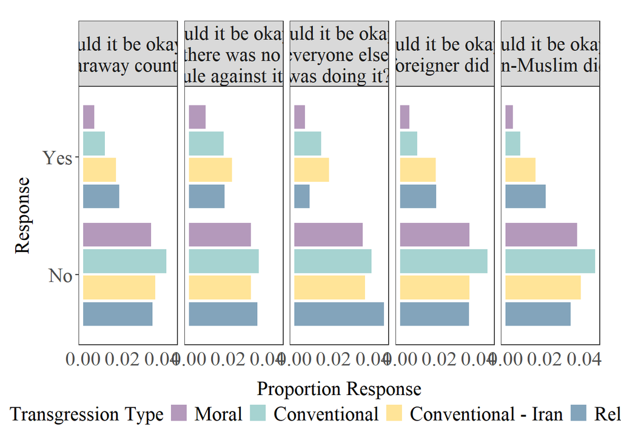

```
# A tibble: 3 × 3
# Groups:   item [2]
  item  answer     n
  <chr> <fct>  <int>
1 bad   1        229
2 good  1          1
3 good  6        228
```

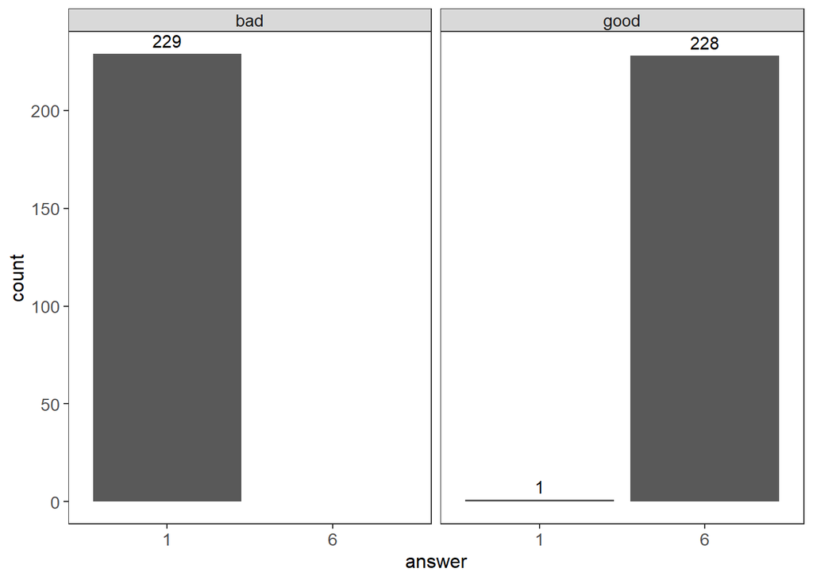

```
# A tibble: 1 × 4
  subid task     item  answer
  <chr> <chr>    <chr> <fct>
1 A0226 practice good  1
```